# GISD - German Index of Socio-Economic Deprivation - Revision 2024

Lola Omar Soliman

2024-12-09

# Intro

Dieses Dokument stellt die Generierung des German Index of Socio-Economic Deprivation vor. Dabei handelt es sich um einen Index sozioökonomischer Deprivation auf regionalräumlicher Ebene, der seit 2012 im Fachgebiet Soziale Determinanten der Gesundheit am RKI entwickelt wurde und seither jährlich aktualisiert wird. Für die Generierung werden Indikatoren der INKAR-Datenbank des BBSR verwendet. Es wird die Revision 2024 vorgestellt, welche Daten aus den Jahren 1998 bis 2021 verwendet.

# Syntax

## 0. Benötigte Pakete und Dateipfadsetzung

```r
library("tidyverse")  # Tidyverse Methoden
library("readxl")     # Excel lesen
library("writexl")    # Excel schreiben
library("haven")      # Stata-dta lesen & schreiben
library("scales")     # Skalierungsfunktionen
library("sf")         # Geospatial Data Manipulation
```

```r
# Skriptpfad als Arbeitspfad setzen
setwd(dirname(rstudioapi::getSourceEditorContext()$path))

latestyear <- 2021 # neuestes Datenjahr vermerken

# Pfaddefinitionen
infiles_dir  <- "../Rohdaten/"
outfiles_dir <- "../../GISD_Release_aktuell/"

# dir.create(outfiles_dir)
# dir.create(paste0(outfiles_dir, "Bund"))
# dir.create(paste0(outfiles_dir, "Bundesland"))
```

## I. Generierung eines ID-Datensatzes

Zunächst wird eine Gebietsreferenz aufbereitet, in welcher alle Gemeinden zusammen mit ihren übergeordneten regionalen Einheiten und deren Kennziffern aufgeführt sind. Quelle ist die Gebietsstandsreferenz der INKAR-Datenbank (https://www.inkar.de). Nachher werden die Indikatoren an diesen “ID-Datensatz” angespielt.

```r
## Gebietsreferenz aufbereiten
# Bundesländer händisch ergänzen
bl_zuordnung <- tibble(gkz_prefix = c("01", "02", "03", "04", "05", "06", "07",
                                      "08", "09", "10", "11", "12", "13", "14", "15", "16"),
                       Bundesland = c("Schleswig-Holstein", "Hamburg", "Niedersachsen",
                                      "Bremen", "Nordrhein-Westfalen", "Hessen",
                                      "Rheinland-Pfalz", "Baden-Württemberg", "Bayern",
                                      "Saarland", "Berlin", "Brandenburg",
                                      "Mecklenburg-Vorpommern", "Sachsen",
                                      "Sachsen-Anhalt", "Thüringen"))

# INKAR-Referenz laden
# (Quelle: https://www.bbsr.bund.de/BBSR/DE/forschung/raumbeobachtung/downloads/download-referenzen.html)
id_dataset <- read_excel(paste0(infiles_dir,
                                "Referenz/raumgliederungen-referenzen-2022.xlsx"),
                         sheet="Gemeindereferenz (inkl. Kreise)",
                         na="NA") %>% # Den String "NA" als missing interpretieren
  slice(-1) %>% # Erste Zeile ist leer, kann raus
  # Erste zwei Ziffern der GKZ extrahieren und Bundesland zuordnen
  mutate(gkz_prefix = substr(str_pad(GEM2022, width = 8, pad = "0"), 1, 2)) %>%
  left_join(bl_zuordnung, by = "gkz_prefix") %>%
  # Die Referenz hat für ab 2021 ein neues Format.
  # Konsistenzhalber wird an das gewohnte Format angeglichen.
  mutate("Gemeindekennziffer" = as.numeric(GEM2022),
         "Name der Gemeinde" = GEM_NAME,
         "Bevoelkerung" = as.numeric(bev22)/100, # Bevölkerung muss in 100 angegeben werden (Wichtig!)
         "GVBKennziffer" = as.numeric(VWG2022),
         "Name des Gemeindeverbands" = VWG_NAME,
         "Kreiskennziffer" = as.numeric(str_sub(KRS2022, end = -4)),
         "Name des Kreises" = KRS_NAME,
         "Raumordnungsregion Nr" = as.numeric(KRO2022),
         "Raumordnungsregion" = KRO_NAME,
         "NUTS2" = N2D2022,
         "NUTS2 Name" = N2D_NAME) %>%
  select(Gemeindekennziffer, "Name der Gemeinde",
         Bevoelkerung,
         GVBKennziffer, "Name des Gemeindeverbands",
         Kreiskennziffer, "Name des Kreises",
         "Raumordnungsregion Nr", Raumordnungsregion,
         NUTS2, "NUTS2 Name",
         Bundesland)

# Auf Missings prüfen
# nrow(id_dataset %>% filter(if_any(everything(), is.na))) # keine Missings
```

## II. Indikatoren einlesen

In diesem Abschnitt werden die für den GISD relevanten Indikatoren eingelesen und zu einen Datensatz zusammengeführt. Die Indikatoren liegen entweder auf Gemeinde-, Gemeindeverbands-, oder Kreisebene vor. Die Faktorenanalysen soll später auf Gemeindeebene durchgeführt werden, weshalb Informationen der höheren Ebenen jeweils an alle untergeordneten Gemeinden angespielt.

```r
## Indikatoren einlesen
# Bilden eines Datensatz-"Skeletts" auf Kreisebene
Basedata <- id_dataset %>%
  distinct(Kreiskennziffer) %>%
  rename(Kennziffer = Kreiskennziffer) %>%
  mutate(Jahr = latestyear)

# Inputliste der hinzuzufügenden Rohdaten erstellen
inputdataset <- list.files(paste0(infiles_dir, "INKAR_1998_",latestyear)) %>%
  .[str_detect(., "\\.xls(x)?$")] # Alle Excel-Files im Ordner auflisten

# Ziel der folgenden Schleife ist ein Datensatz, wo jedes Datenjahr von jeder Gemeinde, jedem Gemeindeverband,
# und jedem Kreis eine eigene Zeile bildet. Jede Zeile wird je nach Gebietsebene mit ihren entsprechenden Indikatoren
# befüllt (z.B. Kreise bekommen Bruttoverdienst usw., Gemeinden bekommen Arbeitslosigkeit usw., ...).

# Einlesen der einzelnen Excelfiles zu den Daten
for(file in inputdataset) {
  suppressMessages(
    myimport <- read_excel(paste0(infiles_dir,
                                  "INKAR_1998_",latestyear,"/",
                                  file),
                           skip = 1,
                           sheet = "Daten") %>%
    rename(Kennziffer = ...1) %>% # Kennziffer-Spalte benennen
    select(-...2, -...3) %>% # Irrelevante Spalten entfernen
    # Umwandeln von Wide zu Long - Das Jahr nun Zeilenweise statt Spaltenweise
    gather(key = Jahr,
           value = Value,
           -Kennziffer,
           convert = TRUE,
           na.rm = TRUE) %>%
    # Sicherheitshalber Datentyp numeric erzwingen
    mutate(Kennziffer = as.numeric(Kennziffer),
           Value = as.numeric(Value)) %>%
    # Sicherheitshalber Datenjahre filtern
    filter(Jahr <= latestyear,
           Jahr >= 1998)
  )

  # Setze Dateinamen des jeweiligen Indikators als Variablenname ein
  names(myimport)[3] <- strsplit(strsplit(file,"_")[[1]][2],"[.]")[[1]][1]

  # Zu Basedata hinzufügen
  Basedata <- full_join(Basedata, myimport,
                        by=c("Kennziffer", "Jahr"))
}

rm(inputdataset, myimport, file)


## Provisorische Anpassungen
# Anpassung 1:
# INKAR gibt keine Daten zu Beschäftigtenabschlüssen vor 2012 raus. Daher wurden ergänzende Daten direkt von der
# Bundesagentur für Arbeit erworben und händisch auf Gebietsstand 2022 harmonisiert.
# Die Daten vor und nach 2012 müssen aber noch zusammengeführt werden.
# Zusätzlich sind es vor 2012 Absolutzahlen und nach 2012 relative Werte.
# Daher werden Werte vor 2012 gegen die Anzahl der SV-Beschäftigten gerechnet.

# Vereinigen der Beschäftigtenabschlüsse
Basedata <- Basedata %>%
  mutate(`BeschaeftigtemitakadAbschluss-pre2012` = `BeschaeftigtemitakadAbschluss-pre2012` / SVBeschaeftigte * 100,
         `BeschaeftigteohneAbschluss-pre2012`    = `BeschaeftigteohneAbschluss-pre2012`    / SVBeschaeftigte * 100,
         BeschaeftigtemitakadAbschluss = if_else(Jahr <= 2011, `BeschaeftigtemitakadAbschluss-pre2012`, BeschaeftigtemitakadAbschluss),
         BeschaeftigteohneAbschluss    = if_else(Jahr <= 2011, `BeschaeftigteohneAbschluss-pre2012`   , BeschaeftigteohneAbschluss)) %>%
  select(-`BeschaeftigtemitakadAbschluss-pre2012`,
         -`BeschaeftigteohneAbschluss-pre2012`,
         - SVBeschaeftigte) # (SV-Beschäftigte bleibt liegen weil nicht mehr benötigt)

# Anpassung 2:
# INKAR hat bisher noch keine Einkommensteuer-Daten für 2020 und 2021 hochgeladen.
# Wir nehmen stattdessen provisorisch einen Datensatz ("IRIS"), der uns auf Anfrage von INKAR zugeschickt wurde.
# Dieser provisorische Datensatz ist auf GVB-Ebene, der künftige INKAR-Datensatz dann aber auf Gemeinde-Ebene.

# Ergänzen der Einkommensteuer 2020-2021 durch IRIS-Daten
# Notiz: Momentan der einzige df auf Gemeindeverbandsebene, nach INKAR-Release am besten händisch GVB binden
suppressMessages(
  iris <- read_csv2(paste0(infiles_dir, #csv2 weil Spalten mit ";" separiert statt ","
                        "INKAR_1998_",latestyear,"/",
                        "IRIS_Einkommenssteuer_Gemeindeverbände_2022.csv"),
                  skip = 1) %>%
  rename(Kennziffer = Gebietskennziffer) %>%
  select(-Name) %>%
  #Umwandeln von Wide zu Long
  pivot_longer(cols = starts_with("Einkommensteuer"),
               names_to = "Jahr",
               names_prefix = "Einkommensteuer ", # Nur das Jahr im Spaltennamen
               values_to = "Einkommensteuer") %>%
  # Sicherheitshalber Datentyp numeric erzwingen
  mutate(Kennziffer = as.numeric(Kennziffer),
         Jahr = as.numeric(Jahr)) %>%
  # Datenjahre filtern
  filter(Jahr %in% c(2020, 2021),
         !is.na(Einkommensteuer))
  )

Basedata <- bind_rows(Basedata, iris) %>%
  arrange(Kennziffer, Jahr)

rm(iris)


## Ab jetzt weiter wie gewohnt
# Tabelle der Indikatoren mit regionaler Tiefe
level_table <- data.frame(Indikator=names(Basedata)[3:length(Basedata)],
                          Tiefe_Indikator=c("Gemeinde", "Gemeinde",
                                            "Kreis", "Gemeinde",
                                            "Kreis", "Kreis", "Kreis",
                                            "Gemeindeverband", # <- Einkommensteuer - Switch auf "Gemeinde" sobald INKAR veröffentlicht
                                            "Kreis", "Kreis"))

# Basisdaten auf Gemeindeebene
Basedata_Gemeindeebene <- Basedata %>%
  select(Gemeindekennziffer = Kennziffer,
         Jahr,
         Arbeitslosigkeit,
         Beschaeftigtenquote,
         ErwerbsfaehigeBevoelkerung) %>%
  filter(Gemeindekennziffer %in% id_dataset$Gemeindekennziffer)

# Basisdaten auf Gemeindeverbandsebene
Basedata_Gemeindeverbandsebene <- Basedata %>%
  select(GVBKennziffer = Kennziffer,
         Jahr,
         Einkommensteuer) %>%
  filter(GVBKennziffer %in% id_dataset$GVBKennziffer)

# Basisdaten auf Kreisebene
Basedata_Kreisebene <- Basedata %>%
  select(Kreiskennziffer = Kennziffer,
         Jahr,
         Bruttoverdienst,
         BeschaeftigtemitakadAbschluss,
         BeschaeftigteohneAbschluss,
         SchulabgaengerohneAbschluss,
         Haushaltseinkommen,
         Schuldnerquote) %>%
  filter(Kreiskennziffer %in% id_dataset$Kreiskennziffer)

# Daten der verschiedenen Ebenen zusammenspielen
# Reminder: Im Gegensatz zu Basedata sind die Gebietsebenen hier "verschachtelt".
# Gemeindeverbände und Kreise sind nicht mehr als extra Zeilen angegeben, sondern als extra Spalten zu jeder Gemeinde.
Workfile <- expand.grid(Gemeindekennziffer=id_dataset$Gemeindekennziffer,
                        Jahr=sort(unique(Basedata$Jahr))) %>%
  left_join(id_dataset, by = "Gemeindekennziffer") %>%
  select(Gemeindekennziffer,
         Jahr,
         GVBKennziffer,
         Kreis = Kreiskennziffer,
         Bevoelkerung,
         Bundesland) %>%
  left_join(Basedata_Gemeindeebene, by = c("Gemeindekennziffer", "Jahr")) %>%
  left_join(Basedata_Gemeindeverbandsebene, by = c("GVBKennziffer", "Jahr")) %>%
  left_join(Basedata_Kreisebene, by = c("Kreis" = "Kreiskennziffer", "Jahr"))

## Datenlücken auf Gemeindeebene um Daten auf Kreisebene ergänzen (1998 - 2000)
# Anspielen der Arbeitslosigkeit und Erwerbsbevölkerung auf Kreisebene
inputdataset_kreisebene <- list.files(paste0(infiles_dir, "INKAR_1998_",latestyear,
                                  "/Indikatoren_Kreisebene/")) %>%
  .[str_detect(., "\\.xls(x)?$")] # Alle Excel Files im Ordner auflisten

for(file in inputdataset_kreisebene) {
  suppressMessages(
    myimport <- read_excel(paste0(infiles_dir,
                                  "INKAR_1998_",latestyear,
                                  "/Indikatoren_Kreisebene/",
                                  file),
                           skip = 1,
                           sheet = "Daten") %>%
    rename(Kreis = ...1) %>% # Kennziffer-Spalte benennen
    select(-...2, -...3) %>% # Irrelevante Spalten entfernen
    # Umwandeln von Wide zu Long
    gather(key = Jahr,
           value = Value,
           -Kreis,
           convert = TRUE,
           na.rm = TRUE) %>%
    #Sicherheitshalber numeric erzwingen
    mutate(Kreis = as.numeric(Kreis),
           Value = as.numeric(Value)) %>%
    # Sicherheitshalber Jahre noch mal filtern
    filter(Jahr <= latestyear,
           Jahr >= 1998)
  )

  # Setze Dateinamen des jeweiligen Indikators als Variablenname ein
  names(myimport)[3] <- strsplit(strsplit(file,"_")[[1]][2],"[.]")[[1]][1]

  # Daten zu Workfile hinzufügen
  Workfile <- full_join(Workfile, myimport,
                        by=c("Kreis", "Jahr"))
}

rm(inputdataset_kreisebene, myimport, file,
   Basedata_Gemeindeebene,
   Basedata_Gemeindeverbandsebene,
   Basedata_Kreisebene)
```

```r
# Finale Aufbereitungsschritte
Workfile <- Workfile %>%
  # Entfernen bevölkerungsloser Gemeinden
  filter(Bevoelkerung > 0) %>%
  # Ersetzen fehlender Gemeindedaten durch Kreisdaten (1998-2000)
  mutate(ErwerbsfaehigeBevoelkerung = ifelse(Jahr < 2001, ErwerbsfaehigeBevoelkerungKreis, ErwerbsfaehigeBevoelkerung),
         Beschaeftigtenquote        = ifelse(Jahr < 2001, BeschaeftigtenquoteKreis, Beschaeftigtenquote),
         Arbeitslosigkeit           = ifelse(Jahr < 2001, ArbeitslosigkeitKreis, Arbeitslosigkeit)) %>%
  # Berechnen des Anteils Arbeitsloser an erwerbsfähiger Bevölkerung
  mutate(Arbeitslosigkeit = Arbeitslosigkeit / ErwerbsfaehigeBevoelkerung * 1000) %>%
  # Korrekturen aufgrund unsauberer Rohdaten
  mutate(
    # Arbeitslosenanteil aus Kreis beziehen wenn er über 100% liegt
    Arbeitslosigkeit = ifelse(Arbeitslosigkeit >= 1, ArbeitslosigkeitKreis / ErwerbsfaehigeBevoelkerungKreis, Arbeitslosigkeit),
    # Arbeitslosenanteil auf 0 setzen wenn erwerbsfähige Bevölkerung == 0
    Arbeitslosigkeit = ifelse(ErwerbsfaehigeBevoelkerung == 0, 0, Arbeitslosigkeit),
    # Beschäftigtenquote bei 80% deckeln
    Beschaeftigtenquote = ifelse(Beschaeftigtenquote > 80, 80, Beschaeftigtenquote)) %>%
  select(-BeschaeftigtenquoteKreis,
         -ArbeitslosigkeitKreis,
         -ErwerbsfaehigeBevoelkerungKreis,
         -ErwerbsfaehigeBevoelkerung) %>% # Erwerbsfähige Bevölkerung nicht mehr benötigt
  arrange(Gemeindekennziffer, Jahr) # Daten sortieren

# Erwerbsfähige Bevölkerung aus level_table löschen
level_table <- level_table[-4,]

# Ende Generierung Basisdatensatz
```

Table 1: Liste der Indikatoren

|  | Indikator | Regionale Tiefe |
| --- | --- | --- |
| 1 | Arbeitslosigkeit | Gemeinde |
| 2 | Beschaeftigtenquote | Gemeinde |
| 3 | Bruttoverdienst | Kreis |
| 5 | BeschaeftigtemitakadAbschluss | Kreis |
| 6 | BeschaeftigteohneAbschluss | Kreis |
| 7 | SchulabgaengerohneAbschluss | Kreis |
| 8 | Einkommensteuer | Gemeindeverband |
| 9 | Haushaltseinkommen | Kreis |
| 10 | Schuldnerquote | Kreis |

## III. Anpassungen

### 1. Verbraucherpreisindex und Logarithmierung

Einkommensteuer, Haushaltseinkommen und Bruttoverdienst werden an den Verbraucherpreisindex (2015 = 100) angepasst und logarithmiert.

```r
# Quelle VBP-Index: <https://www.destatis.de/DE/Themen/Wirtschaft/Preise/Verbraucherpreisindex/Publikationen/Downloads-Verbraucherpreise/verbraucherpreisindex-lange-reihen-pdf-5611103.html>
vbp <- data.frame(Jahr = seq(1998, latestyear),
                  VBindex = c( 78.3,  78.8,
                               79.9,  81.5,  82.6,  83.5,  84.9,
                               86.2,  87.6,  89.6,  91.9,  92.2,
                               93.2,  95.2,  97.1,  98.5,  99.5,
                               100,  100.5,  102,  103.8, 105.3,
                               105.8, 109.1))

# An VBP-Index anpassen und logarithmieren
Workfile <- Workfile %>%
  left_join(vbp, by = "Jahr") %>%
  mutate(Haushaltseinkommen = Haushaltseinkommen / VBindex * 100,
         Bruttoverdienst    = Bruttoverdienst    / VBindex * 100,
         Einkommensteuer    = Einkommensteuer    / VBindex * 100,
         Bruttoverdienst_ln = log(Bruttoverdienst),
         Haushaltseinkommen_ln = log(Haushaltseinkommen),
         # log(x = 0) = NaN. Daher auf 0.75 setzen, so als wäre Einkommensteuer = 2.12
         Einkommensteuer_ln = ifelse(Einkommensteuer == 0, 0.75, log(Einkommensteuer)),
         # log(x < 0) = NaN. Daher auf 0.25 setzen, so als wäre Einkommensteuer = 1.28
         Einkommensteuer_ln = ifelse(Einkommensteuer < 0, 0.25, Einkommensteuer_ln)) %>%
  select(-VBindex)

rm(vbp)
```

### 2. G8/G9-Reformen

Die Bildungsvariablen “Anteil der Schulabgänger mit Hochschulreife” und “Anteil der Schulabgänger ohne Abschluss” werden als Quote relativ zur Gesamtanzahl der Schulabgänger berechnet. Durch die G8-Schulreformen und ihre Zurücknahme ergeben sich deshalb in den Bundesländern zu verschiedenen Zeitpunkten Verzerrungen. Diese Verzerrung wird über ein Regressionsmodell herausgerechnet (Koeffizient der Reformeffekte wird regionsspezifisch vom Indikator abgezogen).

```r
## Adjustment der Schulabgänger-Indikatoren anhand von Reformeffekten
# Generierung der Variablen zur Identifikation der Reformen (G8/G9), Rückker zu G9 (SN_KA) und abweichender Anerkennung von Abschlüssen für GymnasiastInnen (THvor2004)
Workfile <- Workfile %>%
  mutate(G8_jahr = case_when(Kreis < 2000 & Jahr == 2016 ~ 1,
                             Kreis > 1999 & Kreis < 3000 & Jahr == 2010 ~ 1,
                             Kreis > 2999 & Kreis < 4000 & Jahr == 2011 ~ 1,
                             Kreis > 3999 & Kreis < 5000 & Jahr == 2012 ~ 1,
                             Kreis > 4999 & Kreis < 6000 & Jahr == 2013 ~ 1,
                             Kreis > 5999 & Kreis < 7000 & Jahr == 2013 ~ 1,
                             Kreis > 7999 & Kreis < 9000 & Jahr == 2012 ~ 1,
                             Kreis > 8999 & Kreis < 10000 & Jahr == 2011 ~ 1,
                             Kreis > 9999 & Kreis < 11000 & Jahr == 2009 ~ 1,
                             Kreis > 10999 & Kreis < 12000 & Jahr == 2012 ~ 1,
                             Kreis > 11999 & Kreis < 13000 & Jahr == 2012 ~ 1,
                             Kreis > 12999 & Kreis < 14000 & Jahr == 2008 ~ 1,
                             Kreis > 14999 & Kreis < 16000 & Jahr == 2007 ~ 1,
                             TRUE ~ 0), # TRUE = alle anderen Fälle
         G9_jahr =   case_when(Kreis > 7999 & Kreis < 9000 & Jahr == 2020 ~ 1,
                               TRUE ~ 0),
         SN_KA =     case_when(Kreis > 14999 & Kreis < 16000 & Jahr == 2001 ~ 1,
                               TRUE ~ 0),
         THvor2004 = case_when(Kreis > 15999 & Jahr < 2004 ~ 1,
                               TRUE ~ 0)
  )

# Funktion zum Ersetzen der Werte in den von Verzerrungen betroffenen Fällen durch um Reformeffekte bereinigte Quoten
adj_g8 <- function(data, outcome_name) {
  # Datensatz aufbereiten
  regdata <- data %>%
    group_by(Gemeindekennziffer) %>%
    select(Gemeindekennziffer, Jahr,
           G8_jahr, G9_jahr, SN_KA, THvor2004,
           Outcome = paste(outcome_name)) %>%
    mutate(MEAN = mean(Outcome, na.rm = TRUE)) %>%
    ungroup()

  # Regression durchführen
  reg_g8 <- lm(Outcome ~
                 I(Jahr*Jahr*MEAN) + I(Jahr*MEAN) +
                 G8_jahr + G9_jahr + SN_KA + THvor2004,
               data = regdata,
               na.action = "na.exclude")

  # # Werte prüfen
  # print(reg_g8)

  # Koeffizient des Effekts von Indikator abziehen (wenn von Reform betroffen)
  regdata %>%
    mutate(coef_G8 = coef(reg_g8)["G8_jahr"],
           coef_G9 = coef(reg_g8)["G9_jahr"],
           coef_SH = coef(reg_g8)["SN_KA"],
           coef_TH = coef(reg_g8)["THvor2004"],
           Outcome = ifelse(G8_jahr == 1,
                            Outcome - coef_G8,
                            Outcome),
           Outcome = ifelse(G9_jahr == 1,
                            Outcome - coef_G9,
                            Outcome),
           Outcome = ifelse(SN_KA == 1,
                            Outcome - coef_SH,
                            Outcome),
           Outcome = ifelse(THvor2004 == 1,
                            Outcome - coef_TH,
                            Outcome)) %>%
    pull(Outcome) # Bereinigten Wert ausgeben
}

# Adjustment auf Indikator anwenden
Workfile <- Workfile %>%
  mutate(SchulabgaengerohneAbschluss_adj = adj_g8(.,"SchulabgaengerohneAbschluss"))

rm(adj_g8)
```

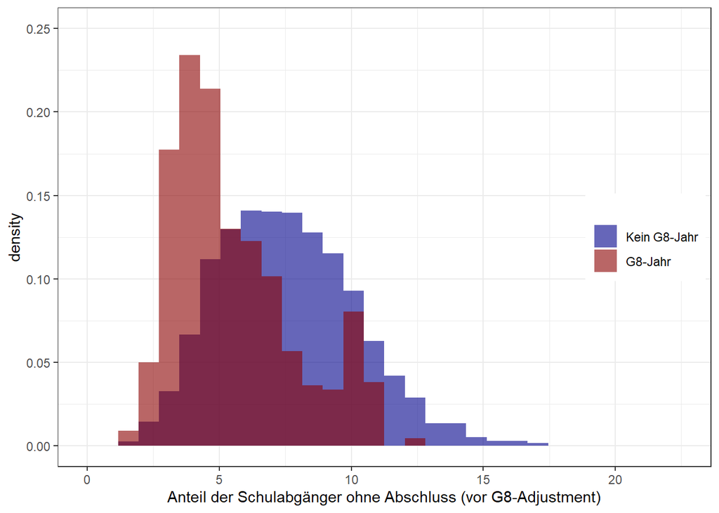

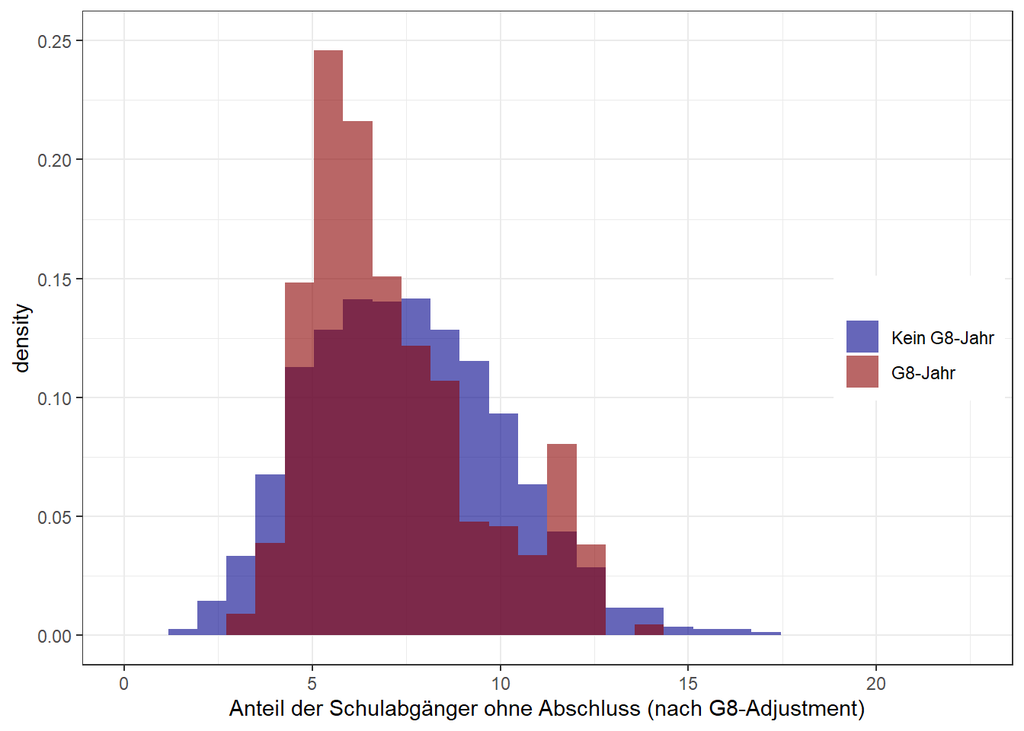

```r
theme_set(theme_bw()) # Plot-Theme einstellen


# Check des Adjustments durch Histogramme
hist_ohneAbschluss <- ggplot(Workfile) +
  geom_histogram(aes(x = SchulabgaengerohneAbschluss, y=..density..,
                     fill = as.factor(G8_jahr)),
                 alpha = 0.6, position = "identity",
                 bins = 30) +
  scale_fill_manual(labels = c("Kein G8-Jahr", "G8-Jahr"),
                    values = c("darkblue", "darkred")) +
  guides(fill = guide_legend(title = "")) +
  theme(legend.position = c(0.9, 0.5)) +
  xlim(0, 22.5) + ylim(0, 0.25) +
  xlab("Anteil der Schulabgänger ohne Abschluss (vor G8-Adjustment)")

hist_ohneAbschluss_adj <- ggplot(Workfile) +
  geom_histogram(aes(x = SchulabgaengerohneAbschluss_adj, y=..density..,
                     fill = as.factor(G8_jahr)),
                 alpha = 0.6, position = "identity",
                 bins = 30) +
  scale_fill_manual(labels = c("Kein G8-Jahr", "G8-Jahr"),
                    values = c("darkblue", "darkred")) +
  guides(fill = guide_legend(title = "")) +
  theme(legend.position = c(0.9, 0.5)) +
  xlim(0, 22.5) + ylim(0, 0.25) +
  xlab("Anteil der Schulabgänger ohne Abschluss (nach G8-Adjustment)")

hist_ohneAbschluss
hist_ohneAbschluss_adj

rm(hist_ohneAbschluss, hist_ohneAbschluss_adj)
```

### 3. Beschäftigtenabschlüsse in den neuen Bundesländern

Aufgrund von Ost-West-Unterschieden (disproportional mehr Abschlüsse in den neuen Bundesländern) wird der Indikator “Beschäftigte ohne Abschluss” ebenfalls durch eine Regression angepasst (Koeffizient des Ost-West-Effekts wird vom Indikator abgezogen).

```r
# Markieren der Kreise
Workfile <- Workfile %>% mutate(ow = ifelse(Kreis < 11000, 0, 1))

# Funktion zum Ersetzen der Werte in den betroffenen Fällen durch um Ost-West-Effekte bereinigte Werte
adj_ow <- function(data, outcome_name) {
  # Datensatz aufbereiten
  regdata <- data %>%
    select(Gemeindekennziffer,
           Jahr,
           ow,
           Outcome = all_of(outcome_name)) %>%
    mutate(Jahr_Dummy = relevel(as.factor(Jahr), ref = "2012")) %>%
    ungroup()

  # Regression durchführen
  reg_ow <- lm(Outcome ~
                 Jahr_Dummy + Jahr_Dummy*ow,
               data = regdata,
               na.action="na.exclude")

  # # Werte prüfen
  # print(reg_ow)

  # Koeffizient des Effekts von Indikator abziehen (wenn Teil der neuen Länder)
  regdata %>%
    mutate(coef_ow = coef(reg_ow)["ow"],
           Outcome = ifelse(ow == 1,
                            Outcome - coef_ow,
                            Outcome)) %>%
    pull(Outcome) # Bereinigten Wert ausgeben
}

# Adjustment auf Indikator anwenden
Workfile <- Workfile %>%
  mutate(BeschaeftigteohneAbschluss_adj = adj_ow(.,"BeschaeftigteohneAbschluss"))

rm(adj_ow)
```

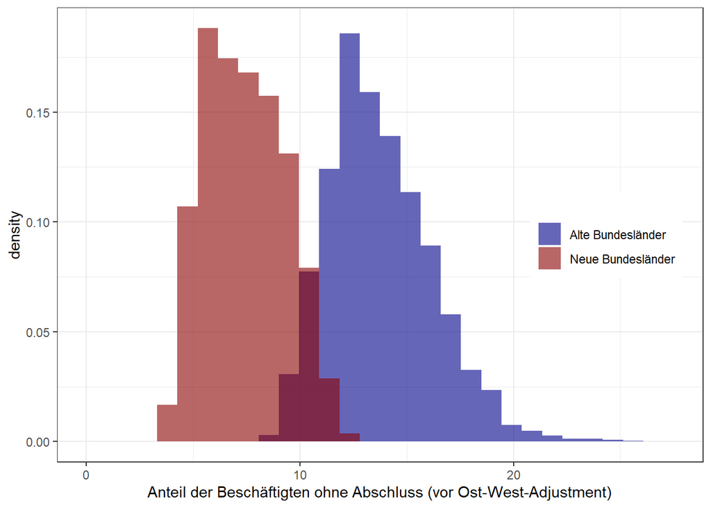

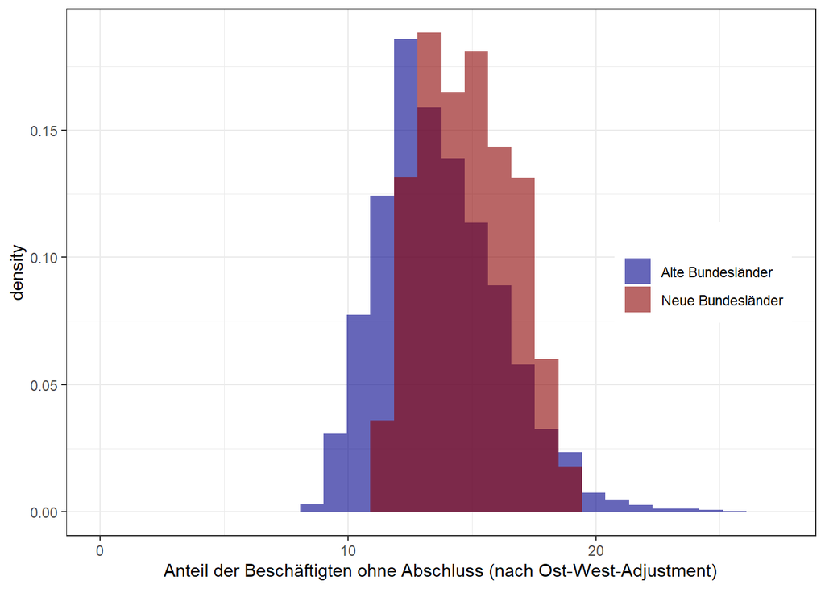

```r
# Check des Adjustments durch Histogramme
hist_ow <- ggplot(Workfile) +
  geom_histogram(aes(x = BeschaeftigteohneAbschluss, y=..density..,
                     fill = as.factor(Kreis>=11000)),
                 alpha = 0.6, position = "identity",
                 bins = 30) +
  scale_fill_manual(labels = c("Alte Bundesländer", "Neue Bundesländer"),
                    values = c("darkblue", "darkred")) +
  guides(fill = guide_legend(title = "")) +
  theme(legend.position = c(0.85, 0.5)) +
  xlim(0, 27.5) +
  xlab("Anteil der Beschäftigten ohne Abschluss (vor Ost-West-Adjustment)")

hist_ow_adj <- ggplot(Workfile) +
  geom_histogram(aes(x = BeschaeftigteohneAbschluss_adj, y=..density..,
                     fill = as.factor(Kreis>=11000)),
                 alpha = 0.6, position = "identity",
                 bins = 30) +
  scale_fill_manual(labels = c("Alte Bundesländer", "Neue Bundesländer"),
                    values = c("darkblue", "darkred")) +
  guides(fill = guide_legend(title = "")) +
  theme(legend.position = c(0.85, 0.5)) +
  xlim(0, 27.5) +
  xlab("Anteil der Beschäftigten ohne Abschluss (nach Ost-West-Adjustment)")

hist_ow
hist_ow_adj

rm(hist_ow, hist_ow_adj)
```

### 4. Messänderung SV-Beschäftigte

Die Zählung der SV-Beschaeftigten wurde graduell zwischen 2011 und 2012 umgestellt. Da SV-Beschäftigte gegen Beschäftigte ohne Abschluss bzw. mit akademischem Abschluss gerechnet wurde, führt die Umstellung zu einer Verzerrung zwischen den Werten vor und nach 2012. Auch diese Verzerrung wird mit einem Regressionsmodell herausgerechnet (Koeffizient des Effekts “Messung vor 2012” wird für Jahre vor 2012 von Indikator abgezogen).

```r
## Beschaeftigte ohne Abschluss
# Werte von 2013 auf 2012 übertragen und Messänderung markieren
Workfile <- Workfile %>%
  group_by(Gemeindekennziffer) %>%
  arrange(Jahr) %>%
  mutate(
    # Betroffene Jahre markieren (Alles vor 2012)
    Messaenderung_Besch = ifelse(Jahr < 2012, 1, 0),
    # Ohne Abschluss für 2012 von 2013 rüberkopieren
    BeschaeftigteohneAbschluss_adj =
      if_else(Jahr == 2012,
              lead(BeschaeftigteohneAbschluss_adj, 1),
              BeschaeftigteohneAbschluss_adj),
    # Mit akad. Abschluss für 2012 von 2013 rüberkopieren
    BeschaeftigtemitakadAbschluss =
      if_else(Jahr == 2012,
              lead(BeschaeftigtemitakadAbschluss, 1),
              BeschaeftigtemitakadAbschluss)) %>%
  ungroup() %>%
  arrange(Gemeindekennziffer, Jahr)

# Datensatz kopieren für Plot nachher
Workfile_preAdj <- Workfile

# Funktion zum Ersetzen der Werte in den betroffenen Jahren durch um Messänderungs-Effekte bereinigte Werte
adj_messaenderung <- function(data, outcome_name) {
  # Datensatz aufbereiten
  regdata <- data %>%
    select(Gemeindekennziffer,
           Jahr,
           Messaenderung_Besch,
           "Outcome"=paste(outcome_name)) %>%
    mutate(MEAN=mean(Outcome, na.rm=TRUE))

  # Regression durchführen
  reg_messaenderung <- lm(Outcome ~
                            I(Jahr*Jahr*MEAN) + I(Jahr*MEAN) + Messaenderung_Besch,
                          data = regdata,
                          na.action="na.exclude")

  # # Werte prüfen
  # print(reg_messaenderung)

  # Koeffizient des Effekts von Indikator abziehen (für Beobachtungen vor 2012)
  regdata %>%
    mutate(coef_mb = coef(reg_messaenderung)["Messaenderung_Besch"],
           Outcome = ifelse(Messaenderung_Besch == 1, # (entspricht Jahr < 2012)
                            Outcome - coef_mb,
                            Outcome)) %>%
    pull(Outcome) # Bereinigten Wert ausgeben
}

# Adjustment auf Indikatoren anwenden
Workfile <- Workfile %>%
  mutate(BeschaeftigteohneAbschluss_adj = adj_messaenderung(.,"BeschaeftigteohneAbschluss_adj"),
         BeschaeftigtemitakadAbschluss_adj = adj_messaenderung(.,"BeschaeftigtemitakadAbschluss")) %>%
  # Sämtliche Adjustment-Hilfsvariablen entfernen
  select(-G8_jahr, -G9_jahr, -SN_KA, -THvor2004,
         -ow, -Messaenderung_Besch)

rm(adj_messaenderung)
```

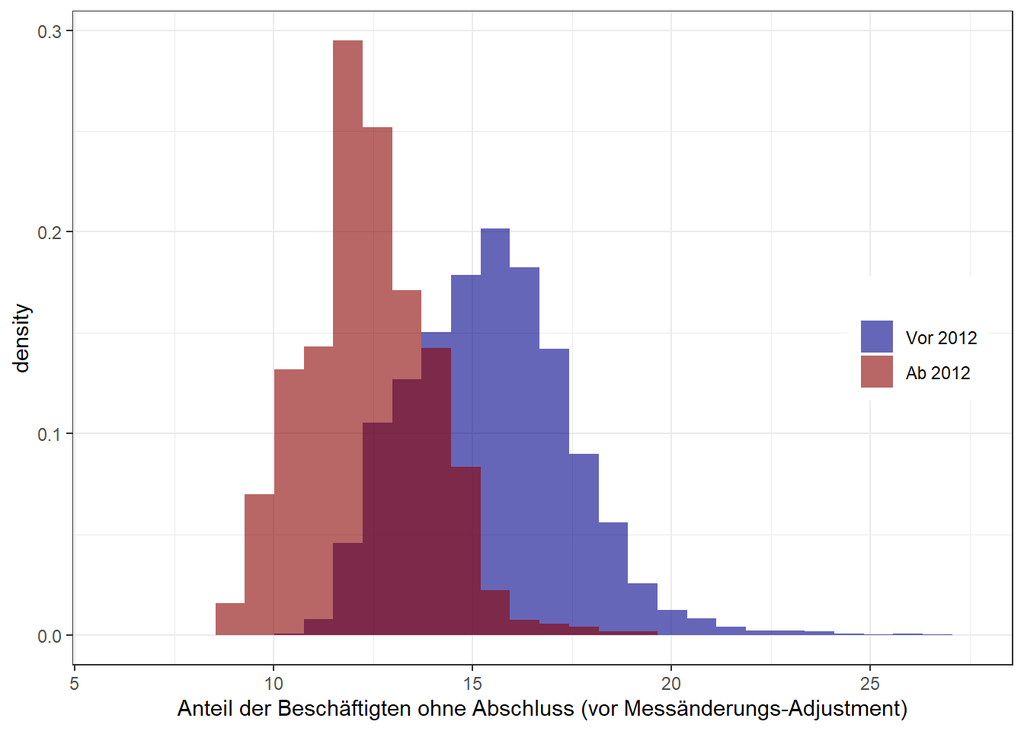

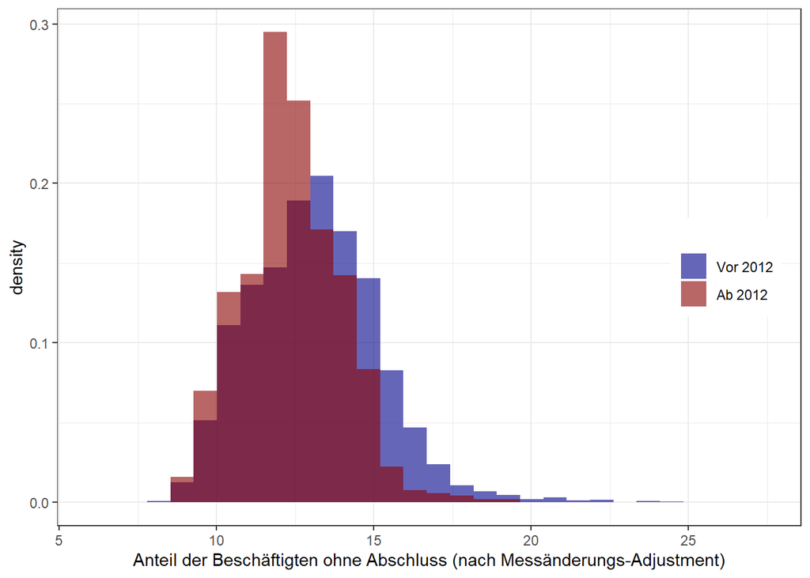

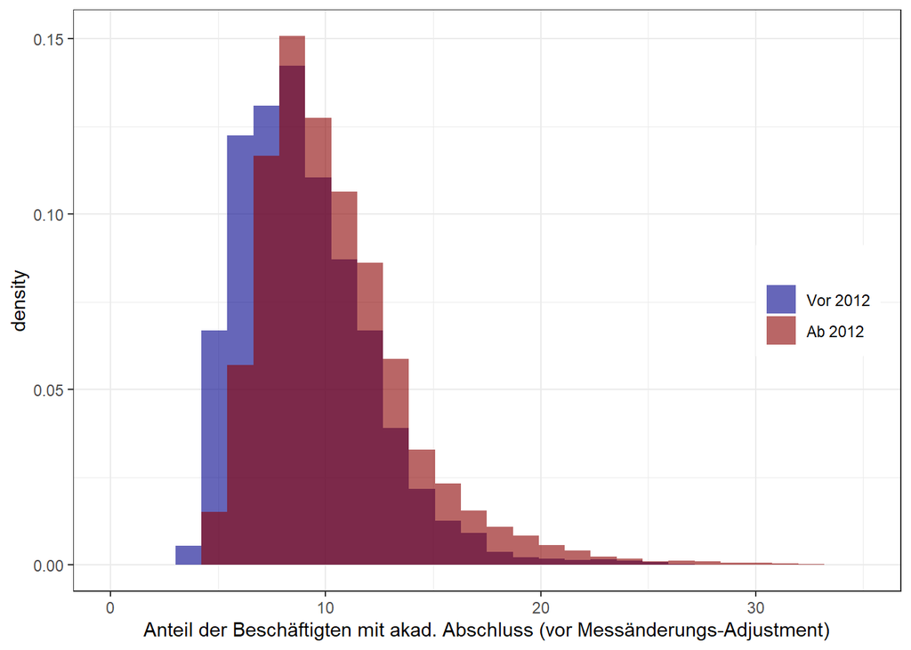

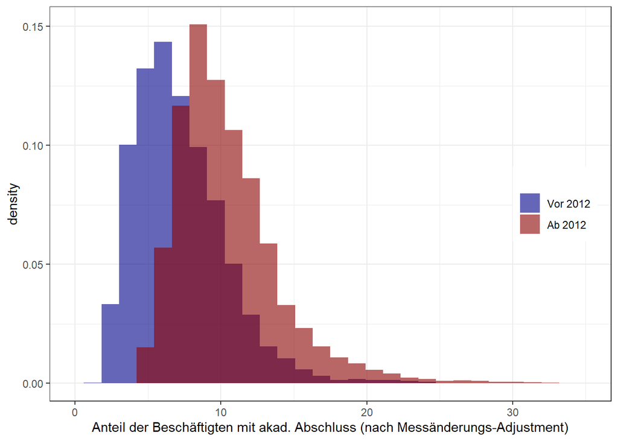

```r
# Check des Adjustments durch Histogramme
hist_messanpassung_ohne <- ggplot(Workfile_preAdj) +
  geom_histogram(aes(x = BeschaeftigteohneAbschluss_adj, y=..density..,
                     fill = as.factor(Jahr>2011)),
                 alpha = 0.6, position = "identity",
                 bins = 30) +
  scale_fill_manual(labels = c("Vor 2012", "Ab 2012"),
                    values = c("darkblue", "darkred")) +
  guides(fill = guide_legend(title = "")) +
  theme(legend.position = c(0.9, 0.5)) +
  xlim(6, 27.5) + xlab("Anteil der Beschäftigten ohne Abschluss (vor Messänderungs-Adjustment)")

hist_messanpassung_ohne_adj <- ggplot(Workfile) +
  geom_histogram(aes(x = BeschaeftigteohneAbschluss_adj, y=..density..,
                     fill = as.factor(Jahr>2011)),
                 alpha = 0.6, position = "identity",
                 bins = 30) +
  scale_fill_manual(labels = c("Vor 2012", "Ab 2012"),
                    values = c("darkblue", "darkred")) +
  guides(fill = guide_legend(title = "")) +
  theme(legend.position = c(0.9, 0.5)) +
  xlim(6, 27.5) + xlab("Anteil der Beschäftigten ohne Abschluss (nach Messänderungs-Adjustment)")

hist_messanpassung_ohne
hist_messanpassung_ohne_adj

hist_messanpassung_akad <- ggplot(Workfile_preAdj) +
  geom_histogram(aes(x = BeschaeftigtemitakadAbschluss, y=..density..,
                     fill = as.factor(Jahr>2011)),
                 alpha = 0.6, position = "identity",
                 bins = 30) +
  scale_fill_manual(labels = c("Vor 2012", "Ab 2012"),
                    values = c("darkblue", "darkred")) +
  guides(fill = guide_legend(title = "")) +
  theme(legend.position = c(0.9, 0.5)) +
  xlim(0, 35) + xlab("Anteil der Beschäftigten mit akad. Abschluss (vor Messänderungs-Adjustment)")

hist_messanpassung_akad_adj <- ggplot(Workfile) +
  geom_histogram(aes(x = BeschaeftigtemitakadAbschluss_adj, y=..density..,
                     fill = as.factor(Jahr>2011)),
                 alpha = 0.6, position = "identity",
                 bins = 30) +
  scale_fill_manual(labels = c("Vor 2012", "Ab 2012"),
                    values = c("darkblue", "darkred")) +
  guides(fill = guide_legend(title = "")) +
  theme(legend.position = c(0.9, 0.5)) +
  xlim(0, 35) + xlab("Anteil der Beschäftigten mit akad. Abschluss (nach Messänderungs-Adjustment)")

hist_messanpassung_akad
hist_messanpassung_akad_adj # Achtung: Anteil akademische Abschlüsse ist in Deutschland über Zeit gestiegen - dass die Werte hier mehr divergieren als vorher ist ein gutes Zeichen!

rm(hist_messanpassung_ohne, hist_messanpassung_ohne_adj,
   hist_messanpassung_akad, hist_messanpassung_akad_adj,
   Workfile_preAdj)
```

## IV. Imputation fehlender Werte

Fehlende Werte auf einem Indikator werden anhand einer Regression imputiert, die vom gemeindespezifischen Zeitreihenmittelwert desselben Indikators informiert wird. Früher wurde anhand der Arbeitslosigkeit und der Schulabgänger mit Hochschulreife imputiert, aber das brachte einen mit diesen Variablen korrelierenden Bias mit sich. Daher wird die Imputation nun nur noch vom Indikator selbst informiert. Am Ende werden noch mal Missings geprüft.

```r
listofdeterminants <- c("Arbeitslosigkeit",
                        "Beschaeftigtenquote",
                        "Bruttoverdienst_ln",
                        "BeschaeftigtemitakadAbschluss_adj",
                        "BeschaeftigteohneAbschluss_adj",
                        "SchulabgaengerohneAbschluss_adj",
                        "Einkommensteuer_ln",
                        "Haushaltseinkommen_ln",
                        "Schuldnerquote")

# Funktion zum Imputieren anhand des Zeitreihenmittelwerts
reg_impute <- function(data, outcome_name) {
  # Datensatz aufbereiten
  regdata <- data %>%
    # Nach Gemeinde gruppieren
    group_by(Gemeindekennziffer) %>%
    select(Gemeindekennziffer,
           Jahr,
           "Outcome"=paste(outcome_name)) %>%
    # Zeitreihen-Mittelwert vermerken
    mutate(MEAN=mean(Outcome, na.rm=TRUE)) %>%
    ungroup()

  # Regression durchführen
  reg_imp <- lm(Outcome ~
                  I(Jahr*Jahr*MEAN) + I(Jahr*MEAN),
                data = regdata,
                na.action="na.exclude")

  # Predicted Value einsetzen
  regdata %>%
    select(Outcome) %>%
    mutate(
      # Predicted Value des Modells notieren
      Imputed = predict(reg_imp,
                        newdata = regdata),
      # Missings mit predicted Value ersetzen
      Outcome=ifelse(is.finite(Outcome),
                     Outcome, Imputed),
      # Implausible (negative) Werte zurück auf 0 setzen
      Outcome=ifelse(Outcome < 0,
                     0, Outcome)) %>%
    pull(Outcome) # Errechneten Wert ausgeben
}

# Über sämtliche Indikatoren imputieren
Impdata <- Workfile %>%
  mutate(Arbeitslosigkeit                 =reg_impute(.,"Arbeitslosigkeit"),
         SchulabgaengerohneAbschluss      =reg_impute(.,"SchulabgaengerohneAbschluss"),
         SchulabgaengerohneAbschluss_adj  =reg_impute(.,"SchulabgaengerohneAbschluss_adj"),
         Beschaeftigtenquote              =reg_impute(.,"Beschaeftigtenquote"),
         Bruttoverdienst                  =reg_impute(.,"Bruttoverdienst"),
         Bruttoverdienst_ln               =reg_impute(.,"Bruttoverdienst_ln"),
         BeschaeftigtemitakadAbschluss    =reg_impute(.,"BeschaeftigtemitakadAbschluss"),
         BeschaeftigtemitakadAbschluss_adj=reg_impute(.,"BeschaeftigtemitakadAbschluss_adj"),
         BeschaeftigteohneAbschluss       =reg_impute(.,"BeschaeftigteohneAbschluss"),
         BeschaeftigteohneAbschluss_adj   =reg_impute(.,"BeschaeftigteohneAbschluss_adj"),
         Einkommensteuer                  =reg_impute(.,"Einkommensteuer"),
         Einkommensteuer_ln               =reg_impute(.,"Einkommensteuer_ln"),
         Haushaltseinkommen               =reg_impute(.,"Haushaltseinkommen"),
         Haushaltseinkommen_ln            =reg_impute(.,"Haushaltseinkommen_ln"),
         Schuldnerquote                   =reg_impute(.,"Schuldnerquote"))

# Ergebnis der Imputation
cat("Übersicht über Indikatoren nach Imputation: \n\n")
```

```
## Übersicht über Indikatoren nach Imputation:
```

```r
summary(Impdata %>% select(all_of(listofdeterminants)))
```

```
##  Arbeitslosigkeit  Beschaeftigtenquote Bruttoverdienst_ln
##  Min.   :0.00000   Min.   : 0.00       Min.   :7.457
##  1st Qu.:0.03406   1st Qu.:49.59       1st Qu.:7.665
##  Median :0.04673   Median :54.35       Median :7.747
##  Mean   :0.05568   Mean   :54.74       Mean   :7.752
##  3rd Qu.:0.06493   3rd Qu.:60.24       3rd Qu.:7.832
##  Max.   :0.19001   Max.   :80.00       Max.   :8.539
##  BeschaeftigtemitakadAbschluss_adj BeschaeftigteohneAbschluss_adj
##  Min.   : 1.703                    Min.   : 7.81
##  1st Qu.: 5.470                    1st Qu.:11.61
##  Median : 7.710                    Median :12.80
##  Mean   : 8.228                    Mean   :12.90
##  3rd Qu.:10.220                    3rd Qu.:14.09
##  Max.   :47.090                    Max.   :24.70
##  SchulabgaengerohneAbschluss_adj Einkommensteuer_ln Haushaltseinkommen_ln
##  Min.   : 1.080                  Min.   :0.250      Min.   :7.088
##  1st Qu.: 5.610                  1st Qu.:5.491      1st Qu.:7.339
##  Median : 7.380                  Median :5.762      Median :7.426
##  Mean   : 7.553                  Mean   :5.668      Mean   :7.421
##  3rd Qu.: 9.270                  3rd Qu.:6.008      3rd Qu.:7.505
##  Max.   :20.270                  Max.   :8.377      Max.   :8.123
##  Schuldnerquote
##  Min.   : 3.670
##  1st Qu.: 7.360
##  Median : 8.940
##  Mean   : 8.853
##  3rd Qu.:10.311
##  Max.   :21.780
```

```r
# Vergleich der Anzahl NAs vor und nach Imputation
missings <- Workfile %>%
  # Reshape auf long (Indikatoren zeilenweise)
  pivot_longer(cols = 7:21,
               names_to = "Indikator",
               values_to = "value") %>%
  # Missings aufsummieren
  group_by(Indikator) %>%
  summarise(PreImputation = sum(is.na(value))) %>%
  # Selbiges für imputierten Datensatz und dann joinen
  left_join(Impdata %>% pivot_longer(cols = 7:21,
                                     names_to = "Indikator",
                                     values_to = "value") %>%
              # Missings aufsummieren
              group_by(Indikator) %>%
              summarise(PostImputation = sum(is.na(value))),
            by = "Indikator")

print(missings)
```

```
## # A tibble: 15 × 3
##    Indikator                         PreImputation PostImputation
##    <chr>                                     <int>          <int>
##  1 Arbeitslosigkeit                              1              0
##  2 BeschaeftigtemitakadAbschluss             43144              0
##  3 BeschaeftigtemitakadAbschluss_adj         43144              0
##  4 Beschaeftigtenquote                          18              0
##  5 BeschaeftigteohneAbschluss                43144              0
##  6 BeschaeftigteohneAbschluss_adj            43144              0
##  7 Bruttoverdienst                           21572              0
##  8 Bruttoverdienst_ln                        21572              0
##  9 Einkommensteuer                               0              0
## 10 Einkommensteuer_ln                            0              0
## 11 Haushaltseinkommen                        21572              0
## 12 Haushaltseinkommen_ln                     21572              0
## 13 SchulabgaengerohneAbschluss                 951              0
## 14 SchulabgaengerohneAbschluss_adj             951              0
## 15 Schuldnerquote                            64716              0
```

```r
rm(reg_impute, missings)
```

## V. Faktorenanalyse (Hauptkomponentenanalyse) und Generierung der Faktorscores

Die Indikatoren werden den einzelnen Teildimensionen des GISD zugewiesen. Für die Faktorenanalysen fallen nur die letzten 20 Datenjahre mit rein.

```r
TS_Arbeitswelt <- Impdata %>%
  filter(Jahr > (latestyear - 20)) %>%
  select(Beschaeftigtenquote,
         Arbeitslosigkeit,
         Bruttoverdienst_ln)

TS_Einkommen <- Impdata %>%
  filter(Jahr > (latestyear - 20)) %>%
  select(Einkommensteuer_ln,
         Haushaltseinkommen_ln,
         Schuldnerquote)

TS_Bildung <- Impdata %>%
  filter(Jahr > (latestyear - 20)) %>%
  select(BeschaeftigtemitakadAbschluss_adj,
         BeschaeftigteohneAbschluss_adj,
         SchulabgaengerohneAbschluss_adj)
```

### Faktorenanalyse

Die Faktorenanalyse basiert auf einer Hauptkomponentenanalyse (PCA) für jede der drei Dimensionen

```r
# PCA für die Arbeitsweltdimension
TS_Arbeitswelt.pca <- prcomp(TS_Arbeitswelt,
                             center = TRUE, scale. = TRUE, retx=TRUE)

plot(TS_Arbeitswelt.pca, main = "Eigenwerte für Dimension Arbeitswelt")

TS_Arbeitswelt.pca <- prcomp(TS_Arbeitswelt,
                             center = TRUE, scale. = TRUE, retx=TRUE,
                             rank. = 1)
TS_Arbeitswelt.pca
```

```
## Standard deviations (1, .., p=3):
## [1] 1.3186461 0.9065693 0.6628006
##
## Rotation (n x k) = (3 x 1):
##                            PC1
## Beschaeftigtenquote  0.4420734
## Arbeitslosigkeit    -0.6285966
## Bruttoverdienst_ln   0.6398730
```

```r
# PCA für die Einkommensdimension
TS_Einkommen.pca <- prcomp(TS_Einkommen,
                           center = TRUE, scale. = TRUE, retx=TRUE)

plot(TS_Einkommen.pca, main = "Eigenwerte für Dimension Einkommen")

TS_Einkommen.pca <- prcomp(TS_Einkommen,
                           center = TRUE, scale. = TRUE, retx=TRUE,
                           rank. = 1)
TS_Einkommen.pca
```

```
## Standard deviations (1, .., p=3):
## [1] 1.4423721 0.8653153 0.4132703
##
## Rotation (n x k) = (3 x 1):
##                              PC1
## Einkommensteuer_ln     0.6349970
## Haushaltseinkommen_ln  0.6387396
## Schuldnerquote        -0.4345003
```

```
## Standard deviations (1, .., p=3):
## [1] 1.2042794 0.8911912 0.8691889
##
## Rotation (n x k) = (3 x 1):
##                                          PC1
## BeschaeftigtemitakadAbschluss_adj  0.5858667
## BeschaeftigteohneAbschluss_adj    -0.5857523
## SchulabgaengerohneAbschluss_adj   -0.5600486
```

[figure not shown]

[figure not shown]

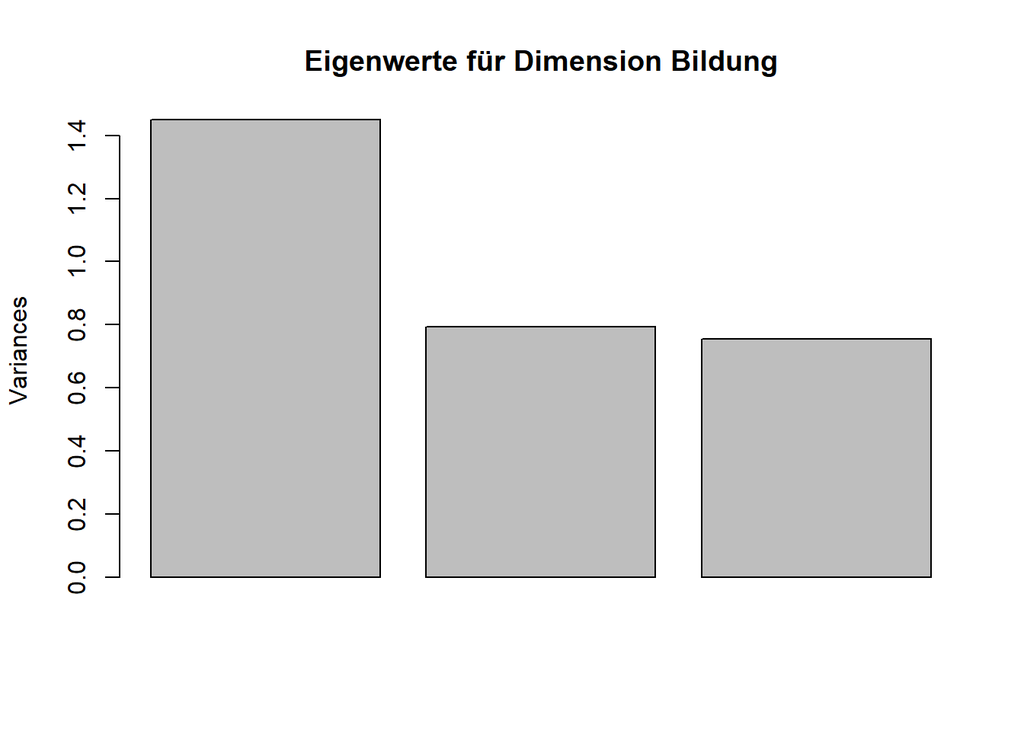

```r
# PCA für die Bildungsdimension
TS_Bildung.pca <- prcomp(TS_Bildung,
                         center = TRUE, scale. = TRUE, retx=TRUE)

plot(TS_Bildung.pca, main = "Eigenwerte für Dimension Bildung")

TS_Bildung.pca <- prcomp(TS_Bildung,
                         center = TRUE, scale. = TRUE, retx=TRUE,
                         rank. =1 )
TS_Bildung.pca
```

### Generierung der Faktorscores

Es werden die GISD-Scores predicted (analog zu Faktorenanalyse-RMD). Dann werden die Dimensionen alle so gepolt, dass sie positiv mit Arbeitslosigkeit korrelieren. Zusätzlich werden die Teilscores jahresweise normiert, zum Gesamtscore aufsummiert, und der Gesamtscore nochmals jahresweise normiert.

```r
# Um die Eigenvektoren in Faktorladungen umzuwandeln müssen Werte in der Scorespalte noch mit den Wurzeln der ersten Eigenwerte multipliziert werden (= Standardabweichung der jeweils ersten Komponente)
Components_A <- data.frame(Variable=rownames(TS_Arbeitswelt.pca$rotation),
                           Dimension="Arbeitswelt",
                           Anteil=unname(TS_Arbeitswelt.pca$rotation^2),
                           Score=unname(TS_Arbeitswelt.pca$rotation * TS_Arbeitswelt.pca$sdev[1]))

Components_B <- data.frame(Variable=rownames(TS_Bildung.pca$rotation),
                           Dimension="Bildung",
                           Anteil=unname(TS_Bildung.pca$rotation^2),
                           Score=unname(TS_Bildung.pca$rotation * TS_Bildung.pca$sdev[1]))

Components_E <- data.frame(Variable=rownames(TS_Einkommen.pca$rotation),
                           Dimension="Einkommen",
                           Anteil=unname(TS_Einkommen.pca$rotation^2),
                           Score=unname(TS_Einkommen.pca$rotation * TS_Einkommen.pca$sdev[1]))

GISD_Components <- rbind(Components_A,
                         Components_B,
                         Components_E) %>%
  mutate(Proportion=round(Anteil*100, digits=1)) %>%
  group_by(Dimension) %>%
  mutate("Anteil am GISD" = round(Proportion/3, digits=1)) %>%
  ungroup() %>%
  select(Variable,
         Dimension,
         Proportion,
         Score,
         "Anteil am GISD")

# Prediction der Scores
Results_raw <- Impdata %>%
  mutate(TS_Arbeitswelt_raw = c(predict(TS_Arbeitswelt.pca, newdata = Impdata)),
         TS_Einkommen_raw = c(predict(TS_Einkommen.pca , newdata = Impdata)),
         TS_Bildung_raw = c(predict(TS_Bildung.pca , newdata = Impdata)))

# Übersicht über Teildimensionen
summary(Results_raw %>% select(TS_Arbeitswelt_raw,
                               TS_Einkommen_raw,
                               TS_Bildung_raw))
```

```
##  TS_Arbeitswelt_raw  TS_Einkommen_raw   TS_Bildung_raw
##  Min.   :-5.981867   Min.   :-8.26684   Min.   :-5.1853
##  1st Qu.:-0.877769   1st Qu.:-0.97615   1st Qu.:-1.1076
##  Median :-0.004867   Median :-0.04614   Median :-0.2338
##  Mean   :-0.132070   Mean   :-0.15525   Mean   :-0.2299
##  3rd Qu.: 0.769849   3rd Qu.: 0.85866   3rd Qu.: 0.5587
##  Max.   : 4.791863   Max.   : 5.89542   Max.   : 6.9691
```

```r
# Korrelationsmatrix der Teildimensionen + Arbeitslosigkeit
cor(Results_raw %>% select(Arbeitslosigkeit,
                           TS_Arbeitswelt_raw,
                           TS_Einkommen_raw,
                           TS_Bildung_raw))
```

```
##                    Arbeitslosigkeit TS_Arbeitswelt_raw TS_Einkommen_raw
## Arbeitslosigkeit          1.0000000         -0.8427178       -0.8593855
## TS_Arbeitswelt_raw       -0.8427178          1.0000000        0.8836622
## TS_Einkommen_raw         -0.8593855          0.8836622        1.0000000
## TS_Bildung_raw           -0.4626193          0.5324589        0.6220255
##                    TS_Bildung_raw
## Arbeitslosigkeit       -0.4626193
## TS_Arbeitswelt_raw      0.5324589
## TS_Einkommen_raw        0.6220255
## TS_Bildung_raw          1.0000000
```

```r
# Dimensionen so polen, dass sie positiv mit Arbeitslosigkeit korrelieren, um Deprivation abzubilden
# (= "wenn Korrelation negativ, dann multipliziere mit -1")
if (cor(Results_raw$Arbeitslosigkeit, Results_raw$TS_Bildung_raw) < 0) {
  Results_raw$TS_Bildung_raw <- Results_raw$TS_Bildung_raw*-1
}
if (cor(Results_raw$Arbeitslosigkeit, Results_raw$TS_Arbeitswelt_raw) < 0) {
  Results_raw$TS_Arbeitswelt_raw <- Results_raw$TS_Arbeitswelt_raw*-1
}
if (cor(Results_raw$Arbeitslosigkeit, Results_raw$TS_Einkommen_raw) < 0) {
  Results_raw$TS_Einkommen_raw <- Results_raw$TS_Einkommen_raw*-1
}

# Korrelationsmatrix der Teildimensionen + Arbeitslosigkeit nach Umpolung
cor(Results_raw %>% select(Arbeitslosigkeit,
                           TS_Arbeitswelt_raw,
                           TS_Einkommen_raw,
                           TS_Bildung_raw))
```

```
##                    Arbeitslosigkeit TS_Arbeitswelt_raw TS_Einkommen_raw
## Arbeitslosigkeit          1.0000000          0.8427178        0.8593855
## TS_Arbeitswelt_raw        0.8427178          1.0000000        0.8836622
## TS_Einkommen_raw          0.8593855          0.8836622        1.0000000
## TS_Bildung_raw            0.4626193          0.5324589        0.6220255
##                    TS_Bildung_raw
## Arbeitslosigkeit        0.4626193
## TS_Arbeitswelt_raw      0.5324589
## TS_Einkommen_raw        0.6220255
## TS_Bildung_raw          1.0000000
```

```r
print(GISD_Components)
```

```
## # A tibble: 9 × 5
##   Variable                          Dimension Proportion  Score `Anteil am GISD`
##   <chr>                             <chr>          <dbl>  <dbl>            <dbl>
## 1 Beschaeftigtenquote               Arbeitsw…       19.5  0.583              6.5
## 2 Arbeitslosigkeit                  Arbeitsw…       39.5 -0.829             13.2
## 3 Bruttoverdienst_ln                Arbeitsw…       40.9  0.844             13.6
## 4 BeschaeftigtemitakadAbschluss_adj Bildung         34.3  0.706             11.4
## 5 BeschaeftigteohneAbschluss_adj    Bildung         34.3 -0.705             11.4
## 6 SchulabgaengerohneAbschluss_adj   Bildung         31.4 -0.674             10.5
## 7 Einkommensteuer_ln                Einkommen       40.3  0.916             13.4
## 8 Haushaltseinkommen_ln             Einkommen       40.8  0.921             13.6
## 9 Schuldnerquote                    Einkommen       18.9 -0.627              6.3
```

```r
# Normieren
Results_raw <- Results_raw %>%
  group_by(Jahr) %>%
  mutate(
    # Teildimensionen normieren (neu: jahresweise statt über gesamte Zeitreihe)
    TS_Arbeitswelt_nrm = rescale(TS_Arbeitswelt_raw),
    TS_Einkommen_nrm = rescale(TS_Einkommen_raw),
    TS_Bildung_nrm = rescale(TS_Bildung_raw),
    # Zu Gesamtscore aufaddieren und noch mal jahresweise normieren
    GISD_Score = rescale(TS_Arbeitswelt_nrm + TS_Einkommen_nrm + TS_Bildung_nrm),
    GISD_Score = round(GISD_Score, digits=5)) %>%
  ungroup()

# Übersicht über Gesamt- und Teilscores nach Normierung
summary(Results_raw %>% select(TS_Arbeitswelt_nrm,
                               TS_Einkommen_nrm,
                               TS_Bildung_nrm,
                               GISD_Score))
```

```
##  TS_Arbeitswelt_nrm TS_Einkommen_nrm TS_Bildung_nrm     GISD_Score
##  Min.   :0.0000     Min.   :0.0000   Min.   :0.0000   Min.   :0.0000
##  1st Qu.:0.3547     1st Qu.:0.3781   1st Qu.:0.4887   1st Qu.:0.4734
##  Median :0.4664     Median :0.4894   Median :0.5938   Median :0.5686
##  Mean   :0.4701     Mean   :0.4991   Mean   :0.5858   Mean   :0.5715
##  3rd Qu.:0.5741     3rd Qu.:0.5985   3rd Qu.:0.6878   3rd Qu.:0.6709
##  Max.   :1.0000     Max.   :1.0000   Max.   :1.0000   Max.   :1.0000
```

```r
rm(TS_Arbeitswelt,
   TS_Arbeitswelt.pca,
   TS_Einkommen,
   TS_Einkommen.pca,
   TS_Bildung,
   TS_Bildung.pca,
   Components_A,
   Components_B,
   Components_E,
   GISD_Components)
```

## VI. Korrektur ausgewählter Ausreißer

Auswahl der Ausreißer basiert auf manueller, visueller Auslese anhand von z-Scores und jahresweise normierten Teilscores. Es geht spezifisch um die Teildimensionen Arbeitswelt und Einkommen. Aus der Selektion werden die rohen (=nicht normierten) Scores in zwei Runden neu imputiert durch Interpolation des Vor- und Nachjahres. (für einen tieferen Einblick siehe Ausreißer_Teildimensionen_[Jahr].Rmd).

```r
# Jahresnormierte Teilscores für Inspektion und Selektion
Scores_raw_long <- Results_raw %>%
  select(Gemeindekennziffer, Jahr, Bundesland,
         Gesamtscore = GISD_Score,
         Arbeitswelt = TS_Arbeitswelt_nrm,
         Einkommen = TS_Einkommen_nrm,
         Bildung = TS_Bildung_nrm) %>%
  # Auf long reshapen
  pivot_longer(cols = c(Gesamtscore, Arbeitswelt, Einkommen, Bildung),
               names_to = "Dimension",
               values_to = "Score") %>%
  # Gemeinde-Jahr-String für Zuordnung nachher
  mutate(gkz_j = paste0(Gemeindekennziffer,"_",as.character(Jahr)))


# Z (relativ zu Gemeindezeitreihe) aufbereiten
Z_ts <- Results_raw %>%
  # Datenbasis für Z: zeitreihennormierte Teilscores
  group_by(Gemeindekennziffer) %>%
  mutate(Arbeitswelt = rescale(TS_Arbeitswelt_raw),
         Einkommen = rescale(TS_Einkommen_raw)) %>%
  # Auf long reshapen
  pivot_longer(cols = c(Arbeitswelt, Einkommen),
               names_to = "Dimension",
               values_to = "Score") %>%
  # Z berechnen
  group_by(Gemeindekennziffer, Dimension) %>%
  mutate(z = (Score - mean(Score)) / sd(Score)) %>%
  ungroup() %>%
  select(Gemeindekennziffer, Jahr,
         Dimension, z)

# Z an den long Datensatz joinen
Scores_raw_long <- Scores_raw_long %>%
  left_join(Z_ts, by = c("Gemeindekennziffer", "Jahr", "Dimension"))

rm(Z_ts)

## Erste Übersicht
# Plotübergreifende Komponente zusammenfassen
plotComponents <- list(scale_x_continuous(breaks = seq(1998, 2021, by = 1),
                                           minor_breaks = NULL),
                        facet_wrap(~ Dimension, ncol = 1,
                                   strip.position = "right",
                                   scales = "free_x"),
                        guides(color=guide_legend(override.aes=list(alpha=1, linewidth=2))))

# Alle Scores
plot_scores <- ggplot(Scores_raw_long,
                      aes(x = Jahr,
                          y = Score,
                          group = Gemeindekennziffer)) +
  geom_line(alpha = 0.3, linewidth = 0.1) +
  labs(subtitle = "Teilscores des GISD vor Imputation",
       y = "Score (jahresweise normiert)") +
  plotComponents

# Genauerer Blick auf Arbeitswelt und Einkommen
plot_ae <- ggplot(Scores_raw_long %>% filter(Dimension == c("Einkommen",
                                                            "Arbeitswelt")),
                  aes(x = Jahr,
                      y = Score,
                      group = Gemeindekennziffer,
                      color = Bundesland)) +
  geom_line(alpha = 0.15, linewidth = 0.5) +
  labs(subtitle = "Einkommens- und Arbeitswelt-Scores vor Imputation",
       y = "Score (jahresweise normiert)") +
  plotComponents


## Selektion
# Arbeitswelt
aus.arb.bw <- Scores_raw_long %>%
  filter(Dimension == "Arbeitswelt",
         Bundesland == "Baden-Württemberg",
          (Jahr == 2002 & Score > 0.5))

aus.arb.mv <- Scores_raw_long %>%
  filter(Dimension == "Arbeitswelt",
         Bundesland == "Mecklenburg-Vorpommern",
          (Jahr == 2002 & Score > 0.85) |
          (Jahr %in% c(2011, 2013, 2015, 2016) & Score > 0.95))

aus.arb.ni <- Scores_raw_long %>%
  filter(Dimension == "Arbeitswelt",
         Bundesland == "Niedersachsen",
          (Jahr %in% c(2002, 2004) & (z > 2 | z < -1)))

aus.arb.nw <- Scores_raw_long %>%
  filter(Dimension == "Arbeitswelt",
         Bundesland == "Nordrhein-Westfalen",
          (Jahr == 2016 & z < -1.5))

aus.arb.rp <- Scores_raw_long %>%
  filter(Dimension == "Arbeitswelt",
         Bundesland == "Rheinland-Pfalz",
          (Jahr == 2002 & z > 2) |
          (Jahr == 2017 & Score > 0.95))

aus.arb.sn <- Scores_raw_long %>%
  filter(Dimension == "Arbeitswelt",
         Bundesland == "Sachsen",
          (Jahr == 2013 & z > 1))

aus.arb.st <- Scores_raw_long %>%
  filter(Dimension == "Arbeitswelt",
         Bundesland == "Sachsen-Anhalt",
          (Jahr == 2013 & z > 1) |
          (Jahr == 2015 & Score > 0.95))

aus.arb.sh <- Scores_raw_long %>%
  filter(Dimension == "Arbeitswelt",
         Bundesland == "Schleswig-Holstein",
          (Jahr == 2002 & z > 2) |
          (Jahr == 2018 & Score > 0.9))

aus.arb.th <- Scores_raw_long %>%
  filter(Dimension == "Arbeitswelt",
         Bundesland == "Thüringen",
          (Jahr == 2002 & z >= 2) |
          (Jahr == 2005 & z < 0) |
          (Jahr == 2018 & Score < 0.1) |
          (Jahr == 2019 & z > 0))

ausreisser_a <- bind_rows(aus.arb.bw,
                          aus.arb.mv,
                          aus.arb.ni,
                          aus.arb.nw,
                          aus.arb.rp,
                          aus.arb.sn,
                          aus.arb.st,
                          aus.arb.sh,
                          aus.arb.th)

# Einkommen
aus.eink.bw <- Scores_raw_long %>%
  filter(Dimension == "Einkommen",
         Bundesland == "Baden-Württemberg",
          (Jahr == 2004 & z < -1) |
          (Jahr == 2015 & (z < -1.5 | z > 0.8)) |
          (Jahr == 2016 & Score < 0.2))

aus.eink.by <- Scores_raw_long %>%
  filter(Dimension == "Einkommen",
         Bundesland == "Bayern",
          (Jahr == 2004 & (z < -1 | z > 4)) |
          (Jahr == 2012 & (z < -1)) |
          (Jahr == 2017))

aus.eink.bb <- Scores_raw_long %>%
  filter(Dimension == "Einkommen",
         Bundesland == "Brandenburg",
         z > 2)

aus.eink.ni <- Scores_raw_long %>%
  filter(Dimension == "Einkommen",
         Bundesland == "Niedersachsen",
         Jahr %in% c(2005, 2007, 2009, 2012),
         Score > 0.75)

aus.eink.nw <- Scores_raw_long %>%
  filter(Dimension == "Einkommen",
         Bundesland == "Nordrhein-Westfalen",
          (Jahr == 2004 & z <= -2) |
          (Jahr == 2011 & z <= -1) |
          (Jahr <= 2017 & z <= -1.5))

ausreisser_e <- bind_rows(aus.eink.bw,
                          aus.eink.by,
                          aus.eink.bb,
                          aus.eink.ni,
                          aus.eink.nw)


## Erste Runde Imputation
Results_imp1 <- Results_raw %>%
  # Gemeinde-Jahr-String für Zuordnung
  mutate(gkz_j = paste0(Gemeindekennziffer,"_",as.character(Jahr))) %>%
  # Interpolieren (Reminder: Es geht um die rohen Scores)
  group_by(Gemeindekennziffer) %>%
  mutate(TS_Arbeitswelt_imp1 = if_else(gkz_j %in% ausreisser_a$gkz_j,
                                      (lag(TS_Arbeitswelt_raw) + lead(TS_Arbeitswelt_raw)) / 2,
                                      TS_Arbeitswelt_raw),
         TS_Einkommen_imp1 = if_else(gkz_j %in% ausreisser_e$gkz_j,
                                    (lag(TS_Einkommen_raw) + lead(TS_Einkommen_raw)) / 2,
                                    TS_Einkommen_raw),
         Imputed = if_else(gkz_j %in% c(ausreisser_e$gkz_j, ausreisser_a$gkz_j),
                           1,
                           0)) %>%
  ungroup() %>%
  # Neu imputierte Teilscores jahresweise normieren
  group_by(Jahr) %>%
  mutate(TS_Arbeitswelt_nrm = rescale(TS_Arbeitswelt_imp1),
         TS_Einkommen_nrm = rescale(TS_Einkommen_imp1),
         # Zu Gesamtscore zusammensetzen und erneut normieren
         GISD_Score = rescale(TS_Arbeitswelt_nrm + TS_Einkommen_nrm + TS_Bildung_nrm)) %>%
  ungroup()
```

```r
Scores_imp1 <- Results_imp1 %>%
  select(Gemeindekennziffer, Jahr, Bundesland,
         Gesamtscore = GISD_Score,
         Arbeitswelt = TS_Arbeitswelt_nrm,
         Einkommen = TS_Einkommen_nrm,
         Bildung = TS_Bildung_nrm,
         contains("TS_"),
         gkz_j) %>%
  # Auf long reshapen
  pivot_longer(cols = c(Gesamtscore, Arbeitswelt, Einkommen, Bildung),
               names_to = "Dimension",
               values_to = "Score")

# Z (relativ zu Gemeindezeitreihe) aufbereiten
Z_ts <- Results_imp1 %>%
  group_by(Gemeindekennziffer) %>%
  mutate(Arbeitswelt = rescale(TS_Arbeitswelt_imp1),
         Einkommen = rescale(TS_Einkommen_imp1)) %>%
  # Auf long reshapen
  pivot_longer(cols = c(Arbeitswelt, Einkommen),
               names_to = "Dimension",
               values_to = "Score") %>%
  # Z berechnen
  group_by(Gemeindekennziffer, Dimension) %>%
  mutate(z = (Score - mean(Score)) / sd(Score)) %>%
  ungroup() %>%
  select(Gemeindekennziffer, Jahr,
         Dimension, z)

# Z an den long Datensatz joinen
Scores_imp1 <- Scores_imp1 %>%
  left_join(Z_ts, by = c("Gemeindekennziffer", "Jahr", "Dimension"))

rm(Z_ts)


## Übersicht nach der ersten Imputation
# Alle Scores
plot_scores_imp1 <- ggplot(Scores_imp1,
                           aes(x = Jahr,
                               y = Score,
                               group = Gemeindekennziffer)) +
  geom_line(alpha = 0.3, linewidth = 0.1) +
  labs(subtitle = "Teilscores des GISD nach 1. Imputation",
       y = "Scores (jahresweise normiert)") +
  plotComponents

# Genauerer Blick auf Arbeitswelt und Einkommen
plot_ae_imp1 <- ggplot(Scores_imp1 %>% filter(Dimension == c("Einkommen",
                                                             "Arbeitswelt")),
                       aes(x = Jahr,
                           y = Score,
                           group = Gemeindekennziffer,
                           color = Bundesland)) +
  geom_line(alpha = 0.15, linewidth = 0.5) +
  labs(subtitle = "Einkommens- und Arbeitswelt-Scores nach 1. Imputation",
       y = "Scores (jahresweise normiert)") +
  plotComponents


## Zweite Runde Selektion
# Arbeitswelt
aus.arb.bw <- Scores_imp1 %>%
  filter(Dimension == "Arbeitswelt",
         Bundesland == "Baden-Württemberg",
          (Jahr == 2007 & z < -1))

aus.arb.mv <- Scores_imp1 %>%
  filter(Dimension == "Arbeitswelt",
         Bundesland == "Mecklenburg-Vorpommern",
          (Jahr == 2014 & Score > 0.95))

aus.arb.sn <- Scores_imp1 %>%
  filter(Dimension == "Arbeitswelt",
         Bundesland == "Sachsen",
          (Jahr == 2014 & Score > 0.9))

aus.arb.th <- Scores_imp1 %>%
  filter(Dimension == "Arbeitswelt",
         Bundesland == "Thüringen",
          (Jahr == 2006 & Score < 0.25))

# Bundesländer zusammenlegen
ausreisser_a_imp1 <- bind_rows(aus.arb.bw,
                               aus.arb.mv,
                               aus.arb.sn,
                               aus.arb.th)

# Einkommen
ausreisser_e_imp1 <- Scores_imp1 %>%
  filter(Dimension == "Einkommen",
         Bundesland == "Baden-Württemberg",
          (Jahr == 2015 & z > -0.2) |
          (Jahr == 2017 & Score < 0.2)) %>%
  # Gemeinde-Jahr-String für Zuordnung erstellen
  mutate(gkz_j = paste0(Gemeindekennziffer,"_",as.character(Jahr)))

rm(aus.arb.bw,
   aus.arb.mv,
   aus.arb.ni,
   aus.arb.nw,
   aus.arb.rp,
   aus.arb.sn,
   aus.arb.st,
   aus.arb.sh,
   aus.arb.th,
   aus.eink.bw,
   aus.eink.by,
   aus.eink.bb,
   aus.eink.ni,
   aus.eink.nw)

## Zweite Runde Imputation
Results_imp2 <- Results_imp1 %>%
  # Interpolieren
  group_by(Gemeindekennziffer) %>%
  mutate(TS_Arbeitswelt_imp2 = if_else(gkz_j %in% ausreisser_a_imp1$gkz_j,
                                      (lag(TS_Arbeitswelt_imp1) + lead(TS_Arbeitswelt_imp1)) / 2,
                                      TS_Arbeitswelt_imp1),
         TS_Einkommen_imp2 = if_else(gkz_j %in% ausreisser_e_imp1$gkz_j,
                                    (lag(TS_Einkommen_imp1) + lead(TS_Einkommen_imp1)) / 2,
                                    TS_Einkommen_imp1),
         Imputed = if_else(gkz_j %in% c(ausreisser_e_imp1$gkz_j, ausreisser_a_imp1$gkz_j),
                           2,
                           Imputed)) %>%
  ungroup() %>%
  # Teilscores jahresweise normieren
  group_by(Jahr) %>%
  mutate(TS_Arbeitswelt_nrm = rescale(TS_Arbeitswelt_imp2),
         TS_Einkommen_nrm = rescale(TS_Einkommen_imp2),
         # Zu Gesamtscore zusammensetzen und erneut normieren
         GISD_Score = rescale(TS_Arbeitswelt_nrm + TS_Einkommen_nrm + TS_Bildung_nrm)) %>%
  ungroup()

Scores_imp2 <- Results_imp2 %>%
  select(Gemeindekennziffer, Jahr, Bundesland,
         Gesamtscore = GISD_Score,
         Arbeitswelt = TS_Arbeitswelt_nrm,
         Einkommen = TS_Einkommen_nrm,
         Bildung = TS_Bildung_nrm,
         contains("TS_"),
         gkz_j) %>%
  # Auf long reshapen
  pivot_longer(cols = c(Gesamtscore, Arbeitswelt, Einkommen, Bildung),
               names_to = "Dimension",
               values_to = "Score")


## Finale Übersicht
# Alle Scores
plot_scores_imp2 <- ggplot(Scores_imp2,
                           aes(x = Jahr,
                               y = Score,
                               group = Gemeindekennziffer)) +
  geom_line(alpha = 0.3, linewidth = 0.1) +
  labs(subtitle = "Teilscores des GISD nach 2. Imputation",
       y = "Scores (jahresweise normiert)") +
  plotComponents

# Genauerer Blick auf Arbeitswelt und Einkommen
plot_ae_imp2 <- ggplot(Scores_imp2 %>% filter(Dimension == c("Einkommen",
                                                             "Arbeitswelt")),
                       aes(x = Jahr,
                           y = Score,
                           group = Gemeindekennziffer,
                           color = Bundesland)) +
  geom_line(alpha = 0.15, linewidth = 0.5) +
  labs(subtitle = "Einkommens- und Arbeitswelt-Scores nach 2. Imputation",
       y = "Scores (jahresweise normiert)") +
  plotComponents


## Ergebnisse in den Arbeitsdatensatz übernehmen
Results_adj <- Results_imp2 %>%
  select(Gemeindekennziffer, Jahr, Bevoelkerung,
         TS_Arbeitswelt_adj = TS_Arbeitswelt_imp2,
         TS_Einkommen_adj = TS_Einkommen_imp2,
         TS_Bildung_adj = TS_Bildung_nrm,
         GISD_Score)
```

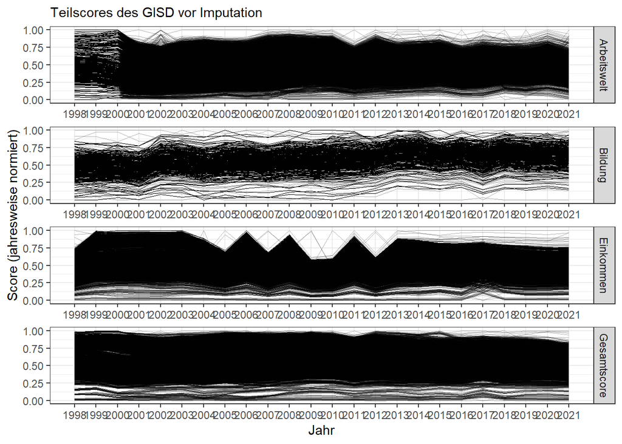

```r
# # Ausschreiben des Datensatzes zur Überprüfung
# write_rds(Results, paste0(outfiles_dir,"Results_adj.rds"))

# # Stata-Kopie für internes Verzeichnis
# write_dta(Results, paste0(check_dir,"Results_adj.dta"))

# Plots outputten
plot_scores
```

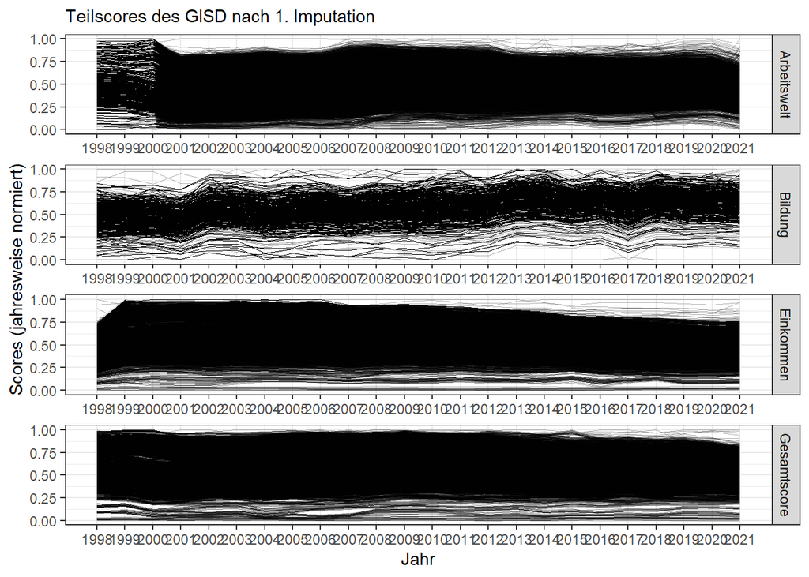

```r
plot_scores_imp1
```

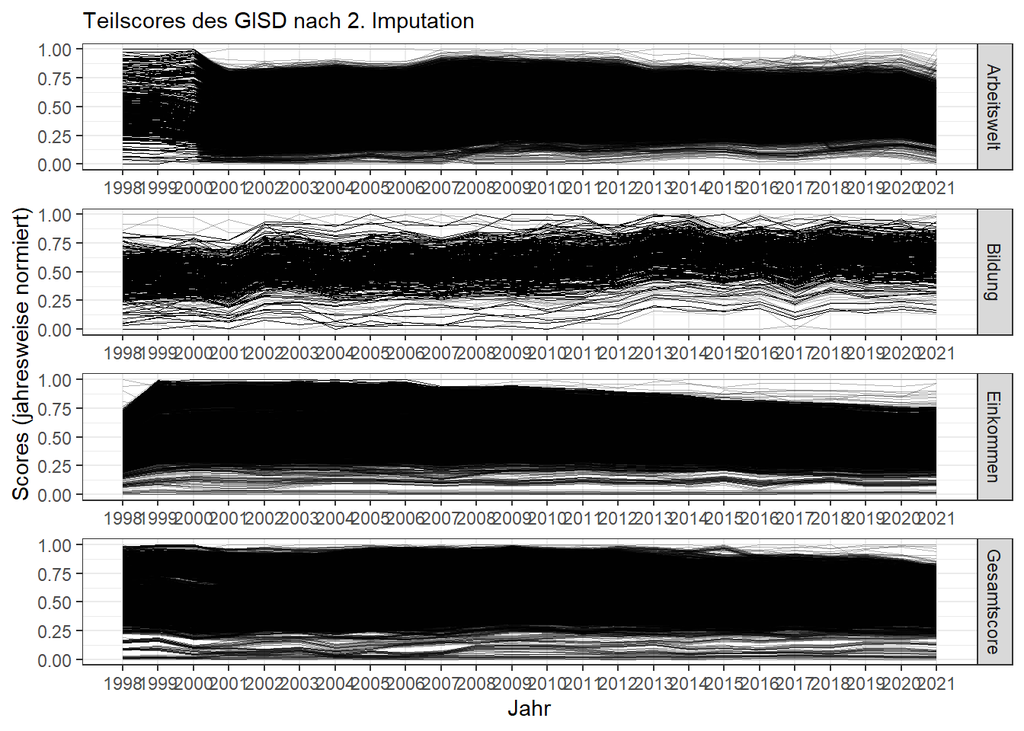

```r
plot_scores_imp2
```

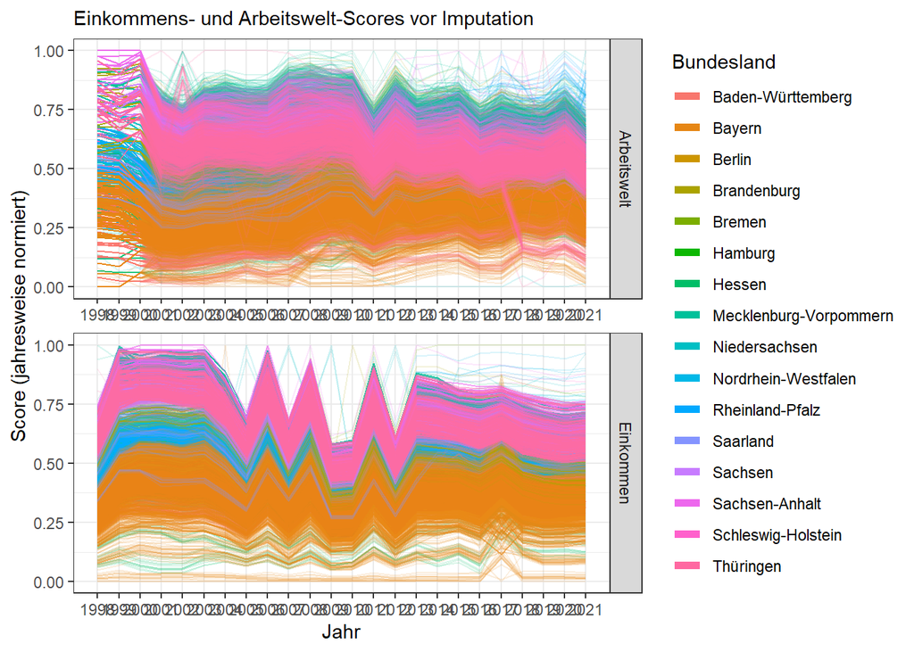

```r
plot_ae
```

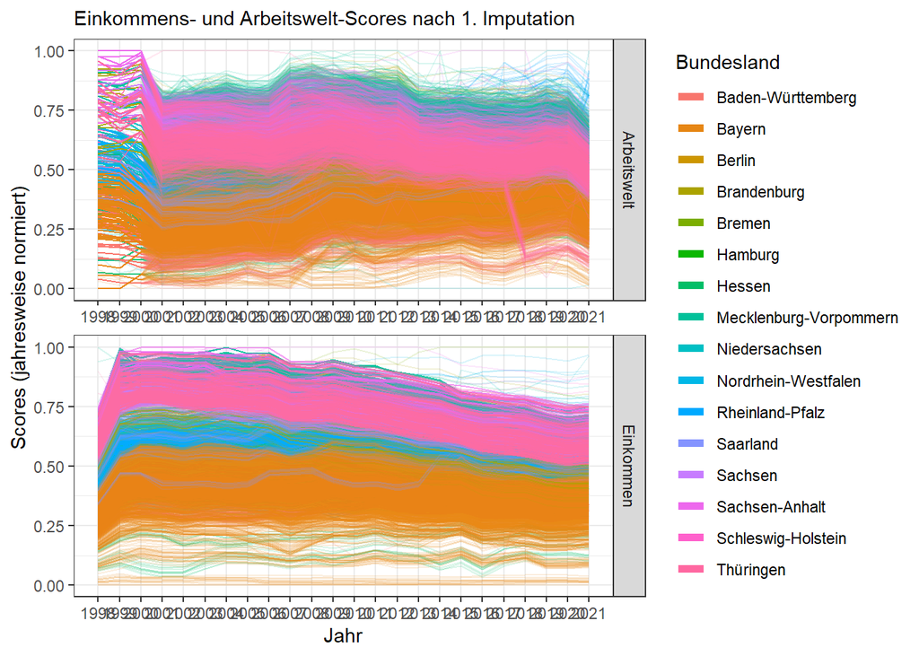

```r
plot_ae_imp1
```

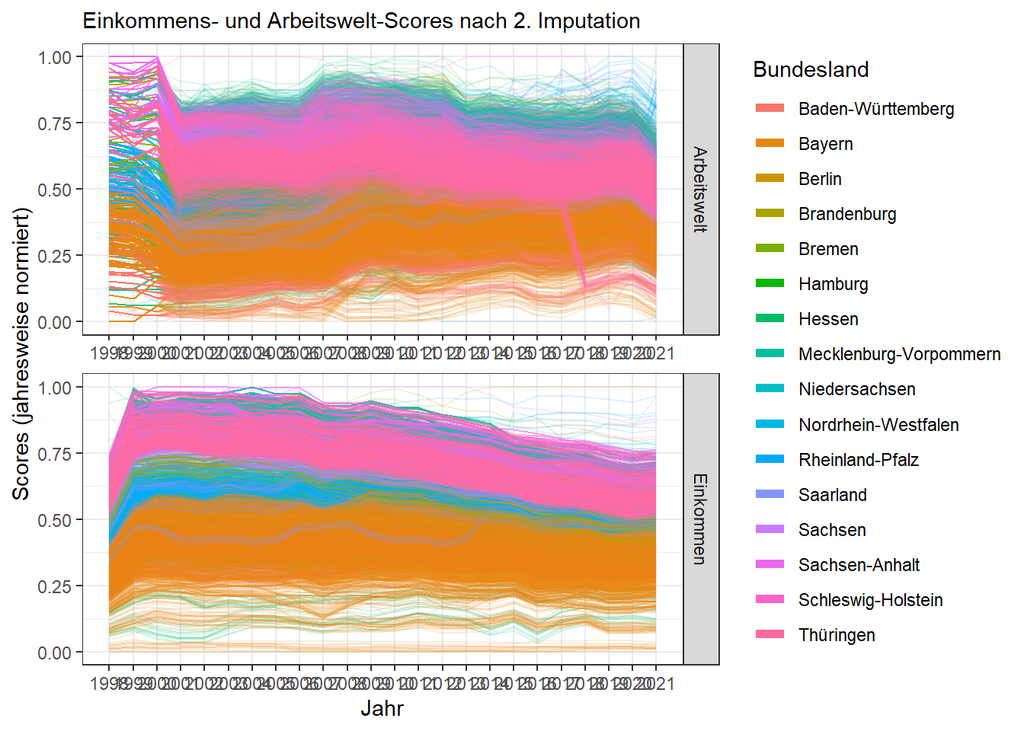

```r
plot_ae_imp2
```

```r
rm(ausreisser_a, ausreisser_a_imp1,
   ausreisser_e, ausreisser_e_imp1,
   Scores_raw_long, Scores_imp1, Scores_imp2,
   Results_imp1, Results_imp2,
   bl_zuordnung, plotComponents,
   plot_ae, plot_ae_imp1, plot_ae_imp2,
   plot_scores, plot_scores_imp1, plot_scores_imp2)
```

## VII. Datenexport - Erstellung der Datensätze

Ausschreiben des GISD-Scores in den Outfiles-Ordner (für Bund und Bundesland; jeweils als .csv oder .dta für Stata)

```r
# Datensatz für die Schleife aufbereiten
RawResult <- Results_adj %>%
   # Verbinde IDs mit Results
  left_join(id_dataset, by=c("Gemeindekennziffer", "Bevoelkerung")) %>%
  rename(year          = Jahr,
         population    = Bevoelkerung,
         gisd_score    = GISD_Score,
         gemeinde_id   = Gemeindekennziffer,
         gvb_id        = GVBKennziffer,
         kreis_id      = Kreiskennziffer,
         ror_id        = `Raumordnungsregion Nr`,
         nuts_2_id     = NUTS2,
         gemeinde_name = `Name der Gemeinde`,
         gvb_name      = `Name des Gemeindeverbands`,
         kreis_name    = `Name des Kreises`,
         ror_name      = Raumordnungsregion,
         nuts_2_name   = `NUTS2 Name`) %>%
   # IDs als String mit Leading Zero abspeichern (bitte jährlich prüfen)
  mutate(gemeinde_id = sprintf("%.8d", gemeinde_id),
         gvb_id      = sprintf("%.9d", as.numeric(gvb_id)), #Besonders hier
         kreis_id    = sprintf("%.5d", as.numeric(kreis_id)),
         ror_id      = sprintf("%.4d", as.numeric(ror_id)))

# Aufschlüsseln der Raumordnungsebenen inkl. entsprechende Variablen
exportlist <- data.frame(
  Kennziffern = c("gemeinde_id","kreis_id","gvb_id","ror_id","nuts_2_id"),
  Namen = c("gemeinde_name","kreis_name","gvb_name","ror_name","nuts_2_name"),
  Label = c("Gemeinde","Kreis","Gemeindeverband","Raumordnungsregion","NUTS2"))

# Funktion, um non-ASCII-Zeichen zu ersetzen (hauptsächlich für bessere Kompatibilität mit Stata)
adjust_filename <- function(names) {
  names %>%
    gsub("ä", "ae", .) %>%
    gsub("ö", "oe", .) %>%
    gsub("ü", "ue", .) %>%
    gsub("ß", "ss", .)
}

# Achtung! Es folgt eine sehr lange Schleife
# Es werden für alle Regionalkennziffern (siehe exportlist) Datensätze generiert und in Ordnern abgelegt
# Für Ebenen über Gemeindelevel werden die Werte aggregiert
for(mykennziffer in exportlist$Kennziffern) {

  # Entsprechende Namens-Variable
  myname <- exportlist %>%
    filter(Kennziffern == mykennziffer) %>%
    pull(Namen)

  # Entsprechendes Raumordnungs-Label
  mylabel <- exportlist %>%
    filter(Kennziffern == mykennziffer) %>%
    pull(Label)

  print(paste("Level:",myname,"Label:",mylabel))

  # Datensatzerstellung
  outputdata <- RawResult

  # Temporärer ID-Datensatz auf der entsprechenden Ebene
  mergedataset <- outputdata %>%
    select(all_of(mykennziffer),
           all_of(myname),
           Bundesland) %>%
    group_by(!!rlang::sym(mykennziffer)) %>%
    filter(row_number()==1) %>%
    ungroup()

  # Bevölkerungsgewichtete Mittelwerte über die regionalen Einheiten bilden
  # Achtung: Referenzrahmen für den Bevölkerungsstand ist das Referenzjahr.
  # Die Varianz der Bevölkerung über die Jahre wird nicht berücksichtigt.
  outputdata.agg <- outputdata %>%
    select(all_of(mykennziffer),
           year, population, gisd_score,
           TS_Bildung_adj, TS_Einkommen_adj, TS_Arbeitswelt_adj) %>%
    group_by(!!rlang::sym(mykennziffer), year) %>%
    summarise(gisd_score = weighted.mean(gisd_score, population),
              TS_Bildung_adj = weighted.mean(TS_Bildung_adj, population),
              TS_Einkommen_adj = weighted.mean(TS_Einkommen_adj, population),
              TS_Arbeitswelt_adj = weighted.mean(TS_Arbeitswelt_adj, population),
              population = sum(population)) %>%
    ungroup() %>%
     # Daten bereinigen
    left_join(mergedataset, by=mykennziffer) %>%
    select(all_of(mykennziffer),
           all_of(myname),
           year, Bundesland, population, gisd_score,
           TS_Bildung_adj, TS_Einkommen_adj, TS_Arbeitswelt_adj) %>%
     # Score normieren und Quintile bilden
    group_by(year) %>%
    mutate(gisd_score = (gisd_score-min(gisd_score))/(max(gisd_score)-min(gisd_score)),
           gisd_5 = findInterval(gisd_score, quantile(gisd_score,   probs=0:5/5 , type=9)),
           gisd_5 = findInterval(gisd_5, c(1:5)),
           gisd_10 = findInterval(gisd_score, quantile(gisd_score, probs=0:10/10 , type=9)),
           gisd_10 = findInterval(gisd_10, c(1:10)),
           gisd_k = findInterval(gisd_5, c(1,2,5)),
           gisd_score=round(gisd_score, digits=5)) %>%
    ungroup()

  # Übersicht
  summary(outputdata.agg %>% select(contains("gisd")))

  # Ausgabe Bund
  mydata <- outputdata.agg %>%
    select(all_of(mykennziffer),
           gisd_score, gisd_5, gisd_10, gisd_k,
           all_of(myname),
           year)

  # CSV exportieren
  write.csv(mydata, paste0(outfiles_dir,"Bund/GISD_Bund_",mylabel,".csv"),
            row.names=FALSE, fileEncoding="UTF-8")

  # Stata-DTA exportieren (und Zeichen bereinigen)
  write_dta(mydata, adjust_filename(paste0(outfiles_dir,
                                           "Bund/GISD_Bund_",mylabel,".dta")))



  # Ausgabe Bundeslandspezifisch ohne Stadtstaaten und nur für Ebenen Kreis und Gemeindeverband
  if (mylabel %in% c("Gemeindeverband","Kreis")) {

    # Aggregieren
    outputdata.bula <- outputdata %>%
      select(all_of(mykennziffer),
             year, population, gisd_score,
             TS_Bildung_adj, TS_Einkommen_adj, TS_Arbeitswelt_adj) %>%
      group_by(!!sym(mykennziffer),year) %>%
      summarise(gisd_score = weighted.mean(gisd_score, population),
                TS_Bildung_adj = weighted.mean(TS_Bildung_adj, population),
                TS_Einkommen_adj = weighted.mean(TS_Einkommen_adj, population),
                TS_Arbeitswelt_adj = weighted.mean(TS_Arbeitswelt_adj, population),
                population = sum(population)) %>%
       # Daten bereinigen
      left_join(mergedataset, by=mykennziffer) %>%
      select(all_of(mykennziffer),
             all_of(myname),
             year, Bundesland, population, gisd_score,
             TS_Bildung_adj, TS_Einkommen_adj, TS_Arbeitswelt_adj) %>%
      filter(!(Bundesland %in% c("Bremen","Hamburg","Berlin"))) %>%
       # Innerhalb des Bundeslandes auf das jeweilige Jahr normieren
       # Frage: Richtig so? Vorher war da eine Loop
      group_by(year, Bundesland) %>%
      mutate(gisd_score=(gisd_score-min(gisd_score))/(max(gisd_score)-min(gisd_score)),
             gisd_score=round(gisd_score, digits=5)) %>%
      ungroup()

  summary(outputdata.bula %>%
            select(contains("gisd")))

  # Ausgabe Bundesländer
  ListeBula <- unique(outputdata.bula$Bundesland)

  for(myland in ListeBula) {
    mydata.bula <- outputdata.bula %>%
      filter(Bundesland==myland) %>%
      ungroup() %>%
      select(gisd_score, mykennziffer, myname, year)

    # CSV exportieren
    write.csv(mydata.bula, paste0(outfiles_dir,
                                  "Bundesland/GISD_",myland,"_",mylabel,".csv"),
              row.names=FALSE, fileEncoding="UTF-8")

    # Stata-DTA exportieren (und Zeichen bereinigen)
    write_dta(mydata.bula, adjust_filename(paste0(outfiles_dir,
                                                  "Bundesland/GISD_",myland,"_",mylabel,".dta")))
    }
  }
}
```

```
## [1] "Level: gemeinde_name Label: Gemeinde"
## [1] "Level: kreis_name Label: Kreis"
## [1] "Level: gvb_name Label: Gemeindeverband"
## [1] "Level: ror_name Label: Raumordnungsregion"
## [1] "Level: nuts_2_name Label: NUTS2"
```

## VIII. Datensätze für PLZ generieren

Hier werden GISD-Scores nach Postleitzahl ausgeschrieben. Das Shapefile enthält Intersects zwischen Gemeinden und Postleitzahlen, sowie die flächengewichtet anteilige Einwohnerzahl der Intersects an Gemeinde-Einwohnern. Es wird der GISD-Score der Gemeinden mit den Intersect-Einwohneranteilen gewichtet und zu PLZ aufaggregiert.

```r
# AGS/Postcode-Intersections-Dataset im sf format
load(paste0(infiles_dir,"SHP/GEM_Zipcode_Intersections_2015.RData"))

# Goettingen hat im Jahr 2017 neue GKZ bekommen.
# Die PLZ-Referenz ist aus 2015, also müssen die GKZ dort geupdated werden
PLZ_update <- read_excel(paste0(infiles_dir, "Referenz/Gebietsstandsaenderungen_Goettingen_PLZ.xlsx"), na="NA") %>%
   # Führende Null nachtragen
  mutate(gkz_alt = sprintf("%.8d", gkz_alt),
         gkz_neu = sprintf("%.8d", gkz_neu))

PLZ.df <- PLZ.df %>%
  ungroup() %>%
  mutate(AGS = as.character(AGS)) %>%
  left_join(., PLZ_update, by = c("AGS" = "gkz_alt")) %>%
  mutate(AGS = ifelse(is.na(gkz_neu), AGS, gkz_neu)) %>%
  select(-gkz_neu, -gemeindename)

for (mykennziffer in c("PLZ2","PLZ3","PLZ4","PLZ5")) {
  myname <- paste0(mykennziffer)
  mylabel <- paste0(mykennziffer)
  print(paste("Level:",myname,"Label:",mylabel))

  # Datensatzerstellung
  outputdata.plz <- Results_adj %>%
    select(AGS = Gemeindekennziffer,
           year= Jahr,
           gisd_score = GISD_Score) %>%
     # Führende Null nachtragen
    mutate(AGS = sprintf("%.8d", AGS)) %>%
     # Daten an PLZ mergen
    left_join(PLZ.df, ., by = "AGS") %>%
     # Bereinigen
    filter(!is.na(mykennziffer) & !is.na(EW_Area) & !is.na(year) & EW_Area>0)

  # GISD aggregieren
  outputdata.plz <- outputdata.plz %>%
    group_by(year, AGS) %>%
    mutate(gisd_score = weighted.mean(gisd_score,EW_Area)) %>%
    group_by_at(vars("year",mykennziffer)) %>%
     # Intersect-Bewohneranteilgewichteter Mittelwert
    summarise(gisd_score = weighted.mean(gisd_score,EW_Area),
              population = sum(EW_Area)) %>%
    group_by(year) %>%
     # Normieren
    mutate(gisd_score = (gisd_score-min(gisd_score)) / (max(gisd_score)-min(gisd_score)),
           gisd_5 = findInterval(gisd_score, quantile(gisd_score, probs=0:5/5, type=9)),
           gisd_5 = findInterval(gisd_5, c(1:5)),
           gisd_10 = findInterval(gisd_score, quantile(gisd_score, probs=0:10/10, type=9)),
           gisd_10 = findInterval(gisd_10, c(1:10)),
           gisd_k = findInterval(gisd_5, c(1,2,5)),
           gisd_score = round(gisd_score, digits = 5))

  # Übersicht
  summary(outputdata)
  head(outputdata)

  mydata <- outputdata.plz %>% ungroup()

  # CSV exportieren
  write.csv(mydata, paste0(outfiles_dir,
                           "Bund/GISD_Bund_",mylabel,".csv"),
            row.names=FALSE, fileEncoding="UTF-8")

  # Stata-DTA exportieren (und Zeichen bereinigen)
  write_dta(mydata, adjust_filename(paste0(outfiles_dir,
                                           "Bund/GISD_Bund_",mylabel,".dta")))
}
```

```
## [1] "Level: PLZ2 Label: PLZ2"
## [1] "Level: PLZ3 Label: PLZ3"
## [1] "Level: PLZ4 Label: PLZ4"
## [1] "Level: PLZ5 Label: PLZ5"
```

```r
rm(mykennziffer, mylabel, myname, mydata, mydata.bula, myland,
   RawResult, mergedataset, exportlist, ListeBula,
   outputdata, outputdata.agg, outputdata.bula, outputdata.plz,
   PLZ.df, PLZ_update, adjust_filename)

### ENDE ###
```